# INLA Mortality 8.2

Jeffrey Wu

2023-11-7

Note: 8.2 means 8 clusters, method 2

### Steps of my analysis

Load all relevant packages:

[output not shown]

Loading and (quickly cleaning) all necessary datasets:

```r
###SoA data

soa.data = read_xlsx("SoA.data.1019.xlsx")

###county_flips are unique identifier for counties
soa.data$county_fips = as.character(soa.data$county_fips) ##change it to character

#IMPORTANT

# This shape file contains the coordinates for county boundaries
##counties is from urbanmap

CA.counties = urbnmapr::counties %>% filter(state_abbv == "CA")

###IF WE WANT TO BOIL DOWN TIME SERIES AND KEEP ALL DATA, SWITCH to CA_newdata below
soa_joint <- left_join(CA.counties, soa.data, by = "county_fips")
## Warning in left_join(CA.counties, soa.data, by = "county_fips"): Detected an unexpected many-to-many relationship between `x` and `y`.
## ℹ Row 1 of `x` matches multiple rows in `y`.
## ℹ Row 1 of `y` matches multiple rows in `x`.
## ℹ If a many-to-many relationship is expected, set `relationship =
##   "many-to-many"` to silence this warning.

#Use with soa.data (full data)
CA_data = soa_joint %>% select(long, lat, county_name.y, Year, Score, Total_Pop,
                               EDUC_Lessthan9, EDUC_college, White_Collar,
                               Unemployment_Rate, Adj_HH_income, Income_Disparity,
                               Individuals_Below_Poverty, Median_Home_Value,
                               Median_Gross_Rent, Housing_No_Telephone,
                               Housing_Incomplete_Plumbing)

### Quick descriptions of SoA data variables
# Score: social deprivation index (SDI) score calculated from the following 11 subindices
# EDUC_Lessthan9: % of population older than 24 with less than 9 years of education
# EDUC_college: % of population older than 24 with at least four years of college education
# White_Collar: % of population older than 15 employed in a white collar occupation
# Unemployment_Rate: unemployment rate for population older than 15
# Adj_HH_income: median household income adjusted for local housing costs
# Income_Disparity: an income disparity ratio
# Individuals_Below_Poverty: % of population below the federal poverty line
# Median_Home_Value: median home value for owned, occupied units
# Median_Gross_Rent: median gross rent for rented units
# Housing_No_Telephone: % of households without a telephone
# Housing_Incomplete_Plumbing: % of households with incomplete plumbing

colnames(CA_data)[3] = "County"

CA_newdata = soa.data[1:58,]
CA_newdata = CA_newdata[,-c(4,7,8)]


###Cal-ViDa data
mortality = read_xlsx("RespiratoryMortality1423.xlsx")
mortality = filter(mortality,Cause_of_Death %in% c("Chronic lower respiratory diseases","Influenza and pneumonia"))
mortality = filter(mortality,Year_of_Death < 2020) #only studying 2014-2019 to avoid COVID pandemic

Population = rep(100000,nrow(mortality))
mortality = cbind(mortality,Population)
```

# Heatmap of population by county

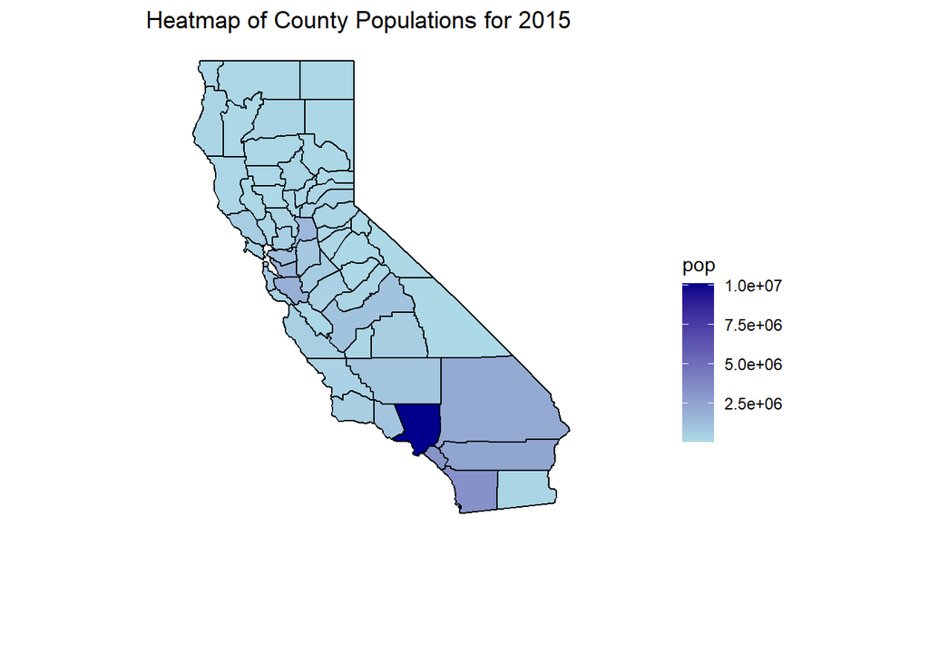

```r
#Initializing map and station locations
ca_map <- map_data("county", region = "california")

#Match population dataset with ca_map
#2010-2019 population data for CA
USpops = read.csv("CA_census_pops1019.csv")
CApops = USpops %>% filter(STNAME == "California") %>% select(CTYNAME,POPESTIMATE2015)
CApops = CApops[-1,]

CApops$CTYNAME = unique(ca_map$subregion)
colnames(CApops) = c("subregion","pop")

merged_data <- merge(ca_map, CApops, by = "subregion", all.x = TRUE)

#Plot
gg_pop <- ggplot() +
  geom_polygon(data = merged_data, aes(x = long, y = lat, group = group, fill = pop),
               color = "black") +
  coord_fixed(ratio = 1.3, xlim = c(-125, -112), ylim = c(30, 42)) +
  theme_void() +
  labs(title = "Heatmap of County Populations for 2015") +
  scale_fill_gradient(low = "lightblue", high = "darkblue")

print(gg_pop)
```

California state with county labels for reference:

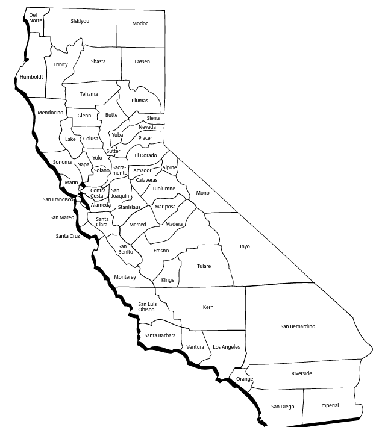

## SKATER clustering

The code below structures the dataframe to be fed into the spatial data frame (SPDF) object. Dimensions are 58 rows by 10 columns (each column is its own year)

```r
###Setting up SPDF for CA counties
CA_sf = st_read(getwd(),"CA_Counties_TIGER2016")
CA_spdf = as_Spatial(CA_sf)

# score_scaled = scale(CA_data$Score)

c_index = unique(CA_data$County)
y_index = unique(CA_data$Year)
SDI_df = matrix(nrow=10,ncol=58)
track1 = 1
track2 = 1

for (i in c_index){
  for (j in y_index){
    scores = CA_data %>% filter(County == i) %>% filter(Year == j) %>% select(Score) %>% unique()
    SDI_df[track1,track2] = scores$Score
    track1 = track1 + 1
  }
  track1 = 1
  track2 = track2 + 1
}

score_scaled = scale(SDI_df) #NEED TO SCALE THE DATA BEFORE FEEDING IT INTO SKATER

#covariates_scale = data.frame(apply(CA_data[,4:16],2,scale))
covariates_scale = data.frame(t(score_scaled))

CA_spdf@data = covariates_scale
```

Using the SPDF from above, we follow the steps of SKATER tutorial (https://www.dshkol.com/post/spatially-constrained-clustering-and-regionalization/) to generate three separate clustering results: (1) Unconstrained/default (2) Clusters have minimum population constraint based on the total population / # of clusters (3) Clusters are comprised of a minimum number of counties (10 for smaller number of clusters, 5 for bigger numbers)

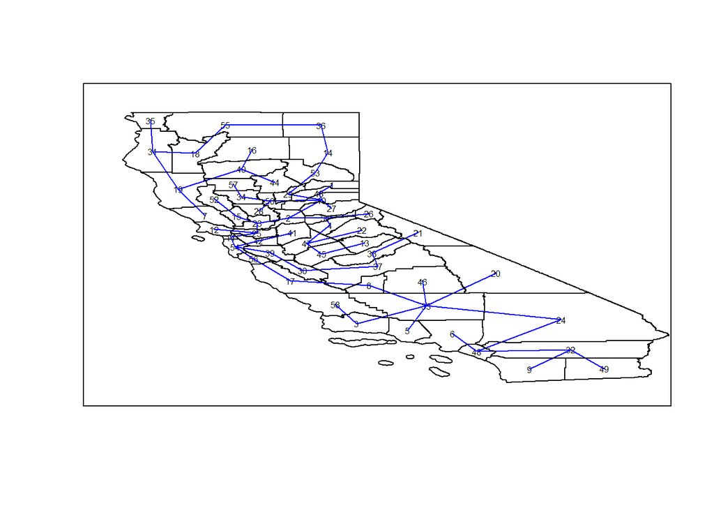

```r
#Identify neighborhood list for counties
CA_nb = poly2nb(CA_spdf)

#summary(CA_nb)

# plot(CA_spdf, main = "With queen")
# plot(CA_nb, coords = coordinates(CA_spdf), col="blue", add = TRUE)

#Calculate edge costs (dissimilarity matrix) based on Euclidean distance
costs <- nbcosts(CA_nb, data = covariates_scale)

###Get adjacency matrix using nb2mat() (SEPARATE STEP FOR BYM model in INLA)
adj = nb2mat(CA_nb,style = "B")

#Style means the coding scheme style used to create the weighting matrix
# B: basic binary coding scheme
# W: row standardized coding scheme
# C: globally standardized coding scheme
# U: values of C / number of neighbors
# S: variance stabilizing coding scheme

#Transform edge costs to spatial weights
ct_w <- nb2listw(CA_nb,costs,style="B")

#Create minimum spanning tree
ct_mst <- mstree(ct_w)

plot(ct_mst,coordinates(CA_spdf),col="blue", cex.lab=0.5)
plot(CA_spdf, add=TRUE)
```

```r
#Run SKATER algorithm to get 8 contiguous clusters (cluster idx is in order of CA_sf)
clus8 <- skater(edges = ct_mst[,1:2], data = covariates_scale, ncuts = 7)

#Add a min population constraint

#Determine an appropriate minimum population threshold based on???
pops_summary = summary(unique(CA_data$Total_Pop))
pops_summary
```

```
##     Min.  1st Qu.   Median     Mean  3rd Qu.     Max.
##    12700    63275   219705   710796   750235 10105722
```

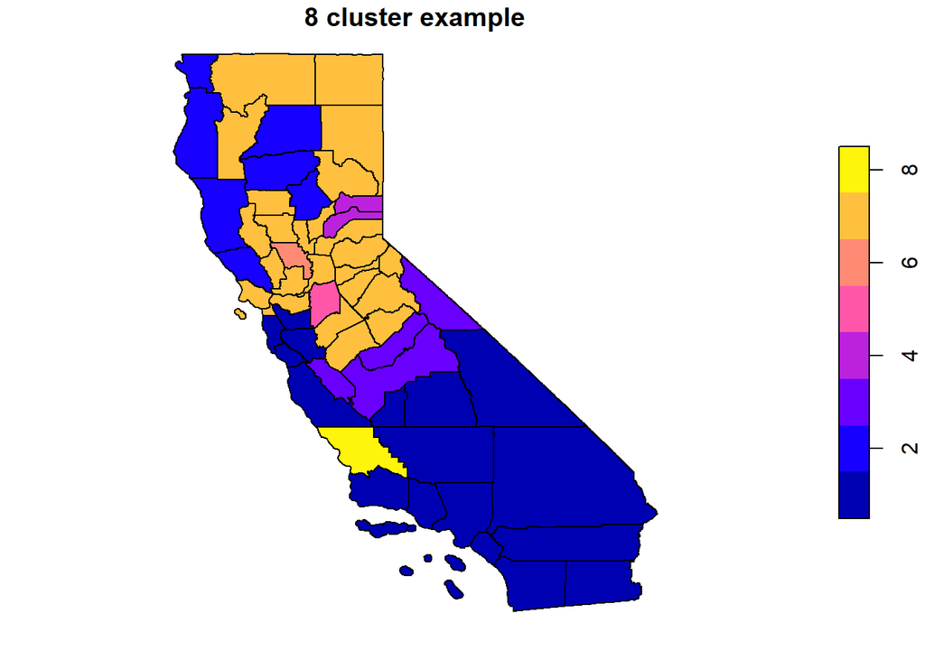

```r
#Idea 1: Use median * (how many counties should be in a cluster at minimum)
min_pop = as.numeric(pops_summary[3] * 5)

#Idea 2: If we assume CA population is 39M, divide total pop by # clusters
min_pop2 = 39000000 / 8

clus8_min <- skater(edges = ct_mst[,1:2],
                     data = covariates_scale,
                     crit = min_pop2,
                     vec.crit = CA_data$Total_Pop,
                     ncuts = 7)

#Add a minimum number of areas in each cluster constraint
clus8_minarea = skater(edges = ct_mst[,1:2], data = covariates_scale, ncuts = 7, 5)


CA_data_cluster = (CA_sf %>% mutate(clus = clus8$groups))

#Plot clustered CA
plot((CA_sf %>% mutate(clus = clus8$groups))['clus'], main = "8 cluster example")
```

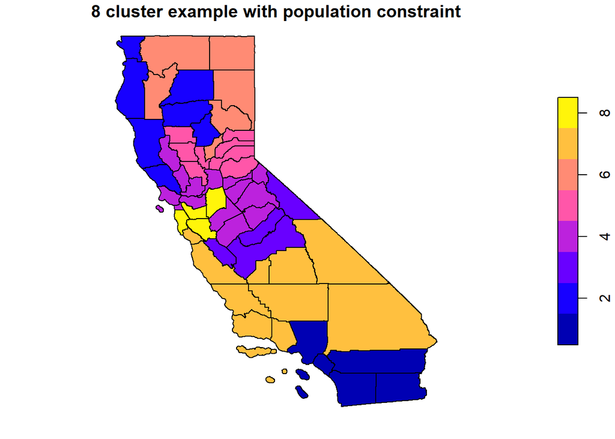

```r
plot((CA_sf %>% mutate(clus = clus8_min$groups))['clus'], main = "8 cluster example with population constraint")
```

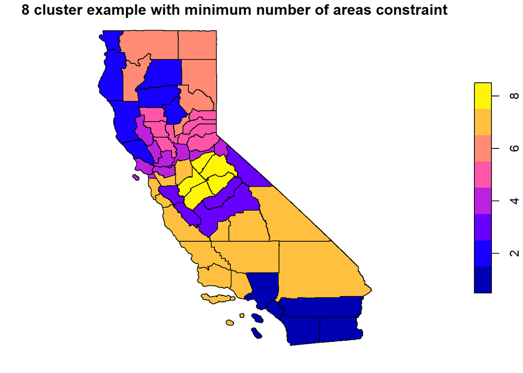

```r
plot((CA_sf %>% mutate(clus = clus8_minarea$groups))['clus'], main = "8 cluster example with minimum number of areas constraint")
```

```r
#plot(CA_sf,col=c("red","green","blue","purple","yellow")[clus8_min$groups],max.plot=17)
```

For reference, here are the cluster labels for each county:

```r
clusterlabels = data.frame(CA_data_cluster$NAME,clus8_min$groups)
names(clusterlabels) = c("counties","Cluster")

o = order(clusterlabels$counties)
clusterlabels = clusterlabels[o,]
rownames(clusterlabels) = NULL

clusterlabels
```

| counties | Cluster |
| --- | --- |
| Alameda | 8 |
| Alpine | 4 |
| Amador | 4 |
| Butte | 2 |
| Calaveras | 4 |
| Colusa | 5 |
| Contra Costa | 4 |
| Del Norte | 2 |
| El Dorado | 5 |
| Fresno | 3 |

[output cut: 48 more lines]

## HUGE graph estimation

This code chunk takes the cluster grouping from SKATER and aggregates the full dataframe from the SPDF (58x10) into a 10x8 matrix (10 time points x 8 clusters) to be fed into the graph estimation package HUGE. The data from each county in a given cluster is aggregated based on a population weighted mean.

HUGE uses glasso to estimate a graph structure based on the aggregated feature data which recall, is the SDI score (socioeconomic status) from the SoA. We use a grid of lambda values under 1 in order to ensure that some edges will be present in the estimates produced by HUGE. This decision is supported by the fact that partial correlations calculated via regression appear to be statistically significant. Based on simulation results, we believe that EBIC is a suitable criterion for choosing the best estimated graph in the huge.select() step.

```r
#Aggregate feature vectors into one vector for each SKATER cluster
CA_cluster = data.frame(CA_sf$NAMELSAD,clus8_min$groups)
names(CA_cluster) = c("County","Cluster")
year = 2010:2019

CA_cluster = left_join(CA_cluster,CA_data,by = "County")

#Get weighted avg value for Score for each cluster for each year
#Create new data matrix of aggregated feature vectors
cluster_features = matrix(NA,nrow = 10,ncol = 8)

for (i in 1:8){
  cluster = CA_cluster %>% filter(Cluster == i)

  for(j in 1:10){
    #Obtain a weighted mean based on population
    vec = cluster %>% filter(Year == year[j]) %>% select(Score,Total_Pop) %>% unique()
    cluster.pop = sum(vec$Total_Pop)
    cluster.popweights = vec$Total_Pop/cluster.pop
    cluster_features[j,i] = weighted.mean(vec$Score,cluster.popweights)
  }
}

#Graph learning w HUGE
out.glasso = huge(cluster_features,lambda = seq(0.95,0.05,by=-0.05),method="glasso")
```

[output not shown]

```r
glasso.stars = huge.select(out.glasso,criterion = "stars",stars.thresh = 0.1)
```

[output not shown]

```r
glasso.ric = huge.select(out.glasso,criterion = "ric")
```

```
## Conducting rotation information criterion (ric) selection....done
## Computing the optimal graph....done
```

```r
glasso.ebic = huge.select(out.glasso,criterion = "ebic")
```

```
## Conducting extended Bayesian information criterion (ebic) selection....done
```

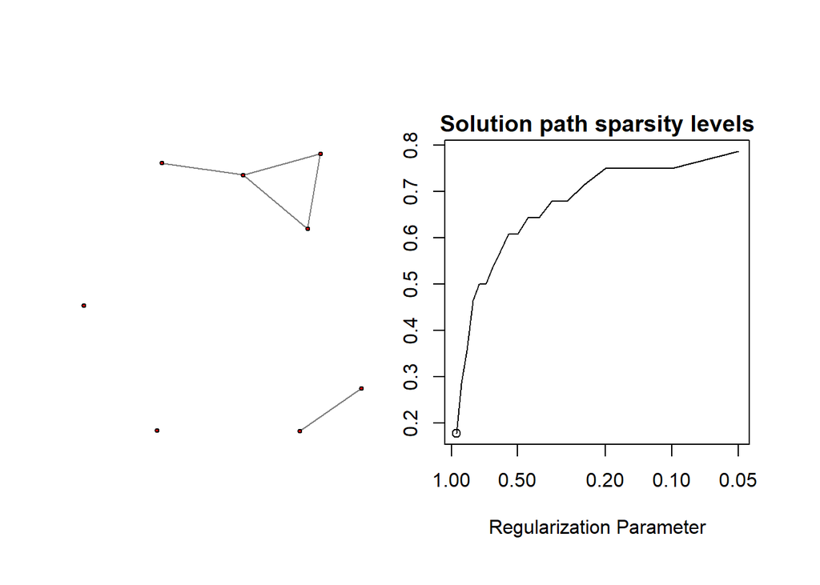

```r
plot(glasso.stars)
```

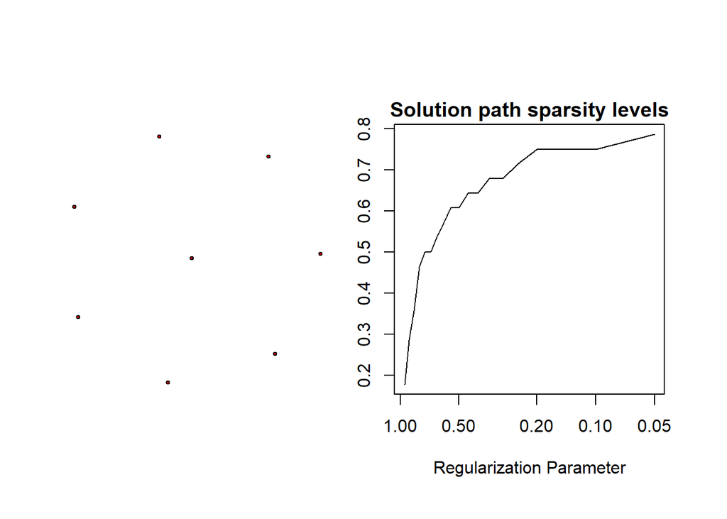

```r
plot(glasso.ric)
```

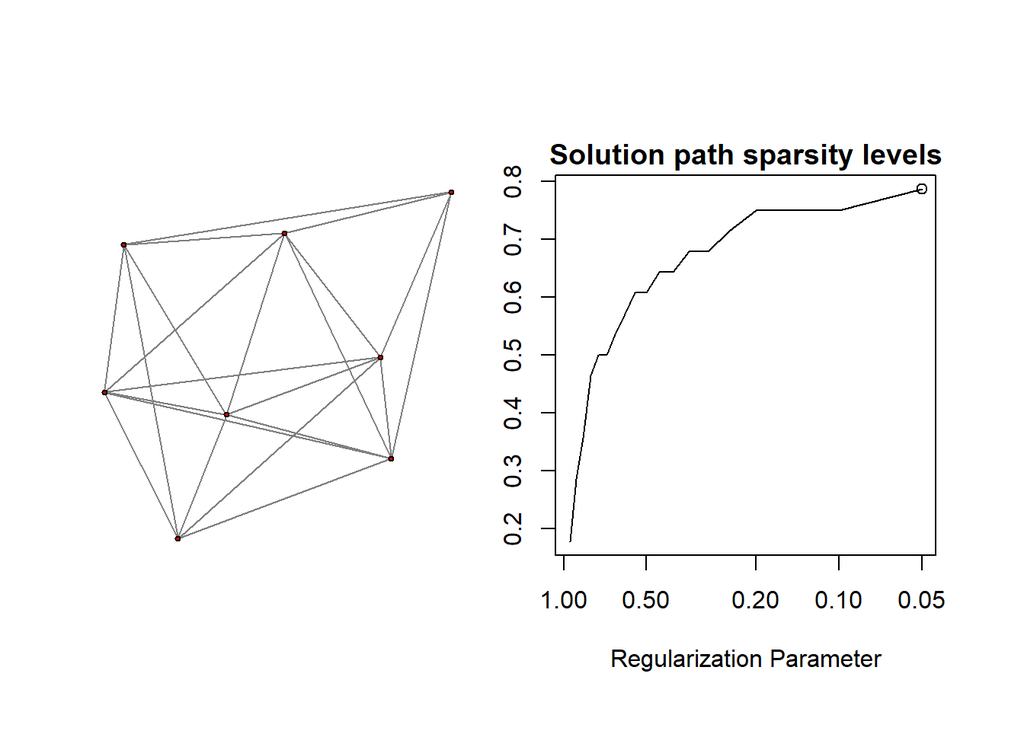

```r
plot(glasso.ebic)
```

```r
huge.est = glasso.ebic$refit
huge.est
```

```
##      [,1] [,2] [,3] [,4] [,5] [,6] [,7] [,8]
## [1,]    0    1    0    1    1    1    1    1
## [2,]    1    0    1    1    1    1    1    0
## [3,]    0    1    0    0    1    1    1    1
## [4,]    1    1    0    0    0    1    0    1
## [5,]    1    1    1    0    0    1    1    1
## [6,]    1    1    1    1    1    0    1    0
## [7,]    1    1    1    0    1    1    0    1
## [8,]    1    0    1    1    1    0    1    0
```

## Transforming estimated adjacency matrix to graph filter H

The code below takes the adjacency matrix estimated in the previous step and transforms it into a graph filter H. The steps are explained in Antonian et al (Gareth’s paper). The cutoff transformation is used for the eigenvalues.

```r
A = as.matrix(huge.est)
p = nrow(A)

#obtain graph Laplacian L
D = diag(p)
for (i in 1:p){
  d = sum(A[,i])
  D[i,i] = d
}

L = D - A

#eigendecomposition of L
Ldecomp = eigen(L)
U = as.matrix(Ldecomp$vectors)
Lambdas = Ldecomp$values

#test
#U %*% (diag(p)*Lambdas) %*% t(U)

#Function implementing cutoff tranform for eigenvalues
cutoff.transform = function(lambdas,q){
  transformed = c()
  cutoff = quantile(lambdas,q)
  for (i in lambdas){
    if(i <= cutoff){
      transformed = c(transformed,1)
    }
    else{
      transformed = c(transformed,0)
    }
  }

  return(transformed)
}

#quantile(Lambdas,2/3)
transformed.L = cutoff.transform(Lambdas,2/3)
eta.L = diag(p)*transformed.L

#obtain graph filter
H = U %*% eta.L %*% t(U)
H
```

```
##             [,1]       [,2]         [,3]         [,4]        [,5]       [,6]
## [1,]  0.43161317  0.1250000 -0.312414934  0.066729185  0.21953629  0.1250000
## [2,]  0.12500000  0.7916667  0.125000000  0.125000000  0.12500000 -0.2083333
## [3,] -0.31241493  0.1250000  0.810757286 -0.006800723  0.06672919  0.1250000
## [4,]  0.06672919  0.1250000 -0.006800723  0.884287195 -0.15960783  0.1250000
## [5,]  0.21953629  0.1250000  0.066729185 -0.159607829  0.74917118  0.1250000
## [6,]  0.12500000 -0.2083333  0.125000000  0.125000000  0.12500000  0.7916667
## [7,]  0.21953629  0.1250000  0.066729185 -0.159607829 -0.25082882  0.1250000
## [8,]  0.12500000 -0.2083333  0.125000000  0.125000000  0.12500000 -0.2083333
##             [,7]       [,8]
## [1,]  0.21953629  0.1250000
## [2,]  0.12500000 -0.2083333
## [3,]  0.06672919  0.1250000
## [4,] -0.15960783  0.1250000
## [5,] -0.25082882  0.1250000
## [6,]  0.12500000 -0.2083333
## [7,]  0.74917118  0.1250000
## [8,]  0.12500000  0.7916667
```

## Downloading EPA data

```r
library(tidyverse)
library(plyr)
library(dplyr)
library(jsonlite)
library(lubridate)
library(ggplot2)
library(maps)
library(mapdata)
library(geosphere)
library(urbnmapr)
library(RAQSAPI)
library(con2aqi)

aqs_credentials("jeffreywu@ucsb.edu","goldswift19")
```

# Get county and pollutant reference codes from EPA

```r
#Get county codes
counties_url = "https://aqs.epa.gov/data/api/list/countiesByState?email=jeffreywu@ucsb.edu&key=goldswift19&state=06&"

countycodes = fromJSON(counties_url)
countycodes = countycodes[[2]]
california_counties = countycodes$code

#Get parameter codes
parameters_url = "https://aqs.epa.gov/data/api/list/parametersByClass?email=jeffreywu@ucsb.edu&key=goldswift19&pc=CRITERIA"

parametercodes = fromJSON(parameters_url)
parametercodes = parametercodes[[2]]

#Do we want to keep Lead PM10 or delete
parametercodes = parametercodes[-7,]

pollutants = data.frame(parametercodes$code)
labels = c("lead","co","so2","no2","o3","pm10","pm25")
pollutants = cbind(pollutants,labels)
```

# Identifying a set of monitoring stations that are well distributed across CA

The goal here is to query all of the EPA measurements for all 7 pollutants and AQI from 2014-2019. The first step is to query all stations in California that collect measurements for at least one of the 7 pollutants.

FUNCTION THAT QUERIES STATION LOCATIONS FOR A GIVEN POLLUTANT

```r
query_aqs_station_data <- function(param,year){
  start_date <- paste0(year, "0101")
  end_date <- paste0(year, "1231")

  url <- paste0("https://aqs.epa.gov/data/api/monitors/byState?email=jeffreywu@ucsb.edu&key=goldswift19&param=", param, "&bdate=", start_date, "&edate=", end_date, "&state=06")

  myData <- fromJSON(url)
  station_data = myData[[2]]

  return(station_data)
}
```

FOR EACH POLLUTANT, GRAB ALL MONITORING STATIONS FOR EACH YEAR

```r
stations_url = "https://aqs.epa.gov/data/api/monitors/byState?email=jeffreywu@ucsb.edu&key=goldswift19&param=88101&bdate=20140101&edate=20141231&state=06"

stations = fromJSON(stations_url)
stations = stations[[2]]

station_data2014_pm2.5 = stations %>% select(latitude,longitude,site_number, local_site_name,county_code,county_name)

#Get monitoring station locations for each pollutant for each year (takes approx 3 min)
all_pollutants_station_data <- list()
for (year in 2014:2019){
  year_data <- lapply(pollutants, query_aqs_station_data, year = year)
  all_pollutants_station_data[[as.character(year)]] <- year_data
}


# 1 - Lead, 2 - Carbon monoxide (CO), 3 - Sulfure dioxide (SO2), 4 - Nitrogen dioxide (NO2)
# 5 - Ozone (O3), 6 - Total PM10, 7 - PM2.5

all_pollutants_station_2014data = all_pollutants_station_data[[1]]
all_pollutants_station_2015data = all_pollutants_station_data[[2]]
all_pollutants_station_2016data = all_pollutants_station_data[[3]]
all_pollutants_station_2017data = all_pollutants_station_data[[4]]
all_pollutants_station_2018data = all_pollutants_station_data[[5]]
all_pollutants_station_2019data = all_pollutants_station_data[[6]]
```

# Identify subset of stations that has best spatial coverage wrt CA state

Starting off with a list of all the stations measuring each parameter/pollutant, we want to identify a subset of stations that measure each pollutant for each county. This overall set of stations (subset for each county combined together) should have a good spatial coverage of the state.

This is difficult because there is not a station in every county measuring each pollutant. So in order to identify a good set of stations to query data from, I first looked up the two largest cities in each county, based on population.

Lat/long for 2 biggest cities (based on population) in each county

```r
citylats = c(37.8044,37.5485,38.7743,38.8071,38.3527,38.3488,39.7285,39.7596,
             38.1231,38.0678,39.2143,39.1546,37.9780,38.0049,41.7558,41.7548,
             38.9399,38.6688,36.7378,36.8252,39.7474,39.5243,40.8021,40.8665,
             32.7920,32.6789,37.3614,37.3855,35.3733,35.7688,36.3275,36.3008,
             38.9582,38.8080,40.4163,40.2840,34.0522,33.7701,36.9613,37.1230,
             37.9735,38.1074,37.4849,37.4320,39.4457,39.4096,37.3022,37.0583,
             41.4871,41.4099,37.6485,38.5149,36.6777,36.6149,38.2975,38.1749,
             39.3280,39.2191,33.8366,33.7455,38.7521,38.7907,39.9341,40.3063,
             33.9806,33.9425,38.5816,38.4088,36.8525,36.8125,34.1083,34.0922,
             32.7157,32.6401,37.7749,37.9780,37.9577,37.7396,35.2828,35.6369,
             37.6879,37.5630,34.9530,34.4208,37.3387,37.3688,36.9741,36.9102,
             40.5865,40.4482,39.6763,39.5595,41.7354,41.3099,38.1041,38.2492,
             38.4404,38.2324,37.6393,37.4946,39.1404,39.1165,40.1785,39.9277,
             40.7310,40.4156,36.3301,36.2077,38.0297,37.9829,34.1975,34.1706,
             38.5449,38.6785,39.1277,39.0954)

citylongs = c(122.2712,121.9886,119.8219,119.7960,120.9327,120.7741,121.8375,121.6219,
              120.8509,120.5385,122.0094,122.1494,122.0311,121.8058,124.2026,124.1580,
              119.9772,120.9872,119.7871,119.7029,122.1964,122.1936,124.1637,124.0828,
              115.5631,115.4989,118.3997,118.4105,119.0187,119.2471,119.6457,119.7829,
              122.6264,122.5583,120.6530,120.5394,118.2437,118.1937,120.0607,120.2602,
              122.5311,122.5697,119.9663,120.0985,123.8053,123.3556,120.4830,120.8499,
              120.5425,120.6791,118.9721,119.4768,121.6555,121.8221,122.2869,122.2608,
              120.1833,121.0611,117.9143,117.8677,121.2880,121.2358,120.8980,121.2319,
              117.3755,117.2297,121.4944,121.3716,121.4016,121.3658,117.2898,117.4350,
              117.1611,117.0842,122.4194,122.0311,121.2908,121.4260,120.6596,120.6545,
              122.4702,122.3255,120.4357,119.6982,121.8853,122.0363,122.0308,121.7569,
              122.3917,122.2978,120.2410,120.8277,122.6345,122.3106,122.2566,122.0405,
              122.7141,122.6367,120.9970,120.8460,121.6169,121.6380,122.2358,122.1792,
              122.9420,123.2100,119.2966,119.3473,119.9741,120.3822,119.1771,118.8376,
              121.7405,121.7733,121.5508,121.5522)
citylongs = -1*citylongs
```

Alameda: Oakland (429082) and Fremont

Alpine: Alpine Village (225) and Mesa Vista

Amador: Ione (8363) and Jackson

Butte: Chico (94776) and Paradise

Calaveras: Rancho Calaveras (5324) and Angels Camp

Colusa: Colusa (5911) and Williams

Contra Costa: Concord (129688) and Antioch

Del Norte: Crescent City (6805) and Bertsch-Oceanview

El Dorado: South Lake Tahoe (22036) and Cameron Park

Fresno: Fresno (530093) and Clovis

Glenn: Orland (7644) and Willows

Humboldt: Eureka (26998) and Arcata

Imperial: El Centro (44120) and Calexico

Inyo: Bishop (3746) and Dixon Lane-Meadow Creek

Kern: Bakersfield (383579) and Delano

Kings: Hanford (56910) and Lemoore

Lake: Clearlake (15384) and Hidden Valley Lake

Lassen: Susanville (15165) and Janesville

Los Angeles: Los Angeles (3990000) and Long Beach

Madera: Madera (65706) and Chowchilla

Marin: San Rafael (58704) and Novato

Mariposa: Mariposa (1526) and Catheys Valley

Mendocino: Fort Bragg (7359) and Willits

Merced: Merced (83316) and Los Banos

Modoc: Alturas (2509) and California Pines

Mono: Mammoth Lakes (8127) and Walker

Monterey: Salinas (156259) and Seaside

Napa: Napa (79263) and American Canyon

Nevada: Truckee (16561) and Grass Valley

Orange: Anaheim (352005) and Santa Ana

Placer: Roseville (139117) and Rocklin

Plumas: East Quincy (2489) and Chester

Riverside: Riverside (330063) and Moreno Valley

Sacramento: Sacramento (508529) and Elk Grove

San Benito: Hollister (39749) and Ridgemark

San Bernandino: San Bernandino (215941) and Fontana

San Diego: San Diego (1426000) and Chula Vista

San Francisco: San Francisco (810000) and Concord

San Joaquin: Stockton (311178) and Tracy

San Luis Obispo: San Luis Obispo (47446) and Paso Robles

San Mateo: Daly City (107008) and San Mateo

Santa Barbara: Santa Maria (107408) and Santa Barbara

Santa Clara: San Jose (1030000) and Sunnyvale

Santa Cruz: Santa Cruz (64725) and Watsonville

Shasta: Redding (91772) and Anderson

Sierra: Loyalton (700) and Downieville

Siskiyou: Yreka (7556) and Mount Shasta

Solano: Vallejo (121913) and Fairfield

Sonoma: Santa Rosa (177586) and Petaluma

Stanislaus: Modesto (215030) and Turlock

Sutter: Yuba City and South Yuba City

Tehama: Red Bluff (14283) and Corning

Trinity: Weaverville (3667) and Post Mountain

Tulare: Visalia (133800) and Tulare

Tuolumne: Phoenix Lake-Cedar Ridge (5108) and Sonora

Ventura: Oxnard (209877) and Thousand Oaks

Yolo: Davis (69289) and Woodland

Yuba: Linda (17773) and Olivehurst

Then, I created the function below to choose a group of stations that are within a certain distance (Haversine distance from the latitude and longitude) of each city that I identified in the previous step. If there are less than 5 stations associated to a given city, the distance threshold (which starts at 100km) is increased by 50km.

FUNCTION THAT SELECTS SET OF STATIONS CLOSEST TO A GIVEN LAT/LONG

```r
# Function to filter stations based on spatial coverage
subset_stations_by_spatial_coverage <- function(station_data, reference_lat, reference_lon, max_distance_km=100) {
  # Calculate distances between stations and reference location
  distances <- distHaversine(
    cbind(station_data$longitude, station_data$latitude),
    c(reference_lon, reference_lat)
  )
  distances <- distances/1000

  # idx =  which(distances == min(distances))
  # #Identify station within min distance to centroid of county
  # station_data_subset <- station_data[idx, ]

  # Subset stations within the specified max_distance_km
  idx = which(distances <= max_distance_km)
  station_data_subset <- station_data[idx, ]
  station_data_subset <- cbind(station_data_subset,distances[idx])

  while (nrow(station_data_subset) < 5){
    max_distance_km = max_distance_km + 50
    station_data_subset = subset_stations_by_spatial_coverage(station_data,
                              reference_lat, reference_lon, max_distance_km)
  }

  return(station_data_subset)
}

# # Construct the subset of stations based on spatial coverage criteria (test)
# reference_lat = citylats[3]
# reference_lon = citylongs[3]
# max_distance_km = 100
#
# subset_stations <- subset_stations_by_spatial_coverage(station_data2014_pm2.5, reference_lat, reference_lon, max_distance_km)
#
# # Print the subset of stations
# print(subset_stations)
```

```r
# Obtain centroid lat/longs for each county
CA.counties2 = read.csv("counties.ca.data.csv")
ca.coordinates = data.frame(CA.counties2$county,CA.counties2$lat,CA.counties2$lng)
colnames(ca.coordinates) = c("county","lat","long")

ca.coordinates = ca.coordinates[order(ca.coordinates$county),]
row.names(ca.coordinates) = NULL
```

IMPORTANT FUNCTION:

Given a dataset containing station locations/codes for a given pollutant and year, the function below selects 5-20 stations that are closest to the lat/longs for the two biggest cities in each county and puts the station information (code, lat, long, etc) into a dataframe.

```r
#Function that finds best monitoring station for each county for a specific pollutant for a specific year
# 1 - Lead, 2 - Carbon monoxide (CO), 3 - Sulfure dioxide (SO2), 4 - Nitrogen dioxide (NO2)
# 5 - Ozone (O3), 6 - Total PM10, 7 - PM2.5

best_stations = function(stationdata,pollutant){

  subset_list = list()

  #Load lat/longs for 58x2 cities into dataframe
  CA.coords = data.frame(rep(countycodes$value_represented,each = 2),citylats,citylongs)
  colnames(CA.coords) = c("County","Lat","Long")

  #Find closest station for each county centroid using subset_stations_by_spatial_coverage function
  for (i in 1:nrow(CA.coords)){
  reference_lat = CA.coords$Lat[i]
  reference_lon = CA.coords$Long[i]
  max_distance_km = 100

  subset_stations <- subset_stations_by_spatial_coverage(stationdata[[pollutant]], reference_lat, reference_lon, max_distance_km)
  subset_list[[i]] = subset_stations
  }

  #Combine pairs of city lists together
  subset_list2 = list()
  sequence = seq(2,116,2)
  for(i in sequence){
    combine = rbind(subset_list[[i]],subset_list[[i-1]])
    subset_list2[[i-1]] = combine
  }
  subset_list2 =subset_list2[!sapply(subset_list2,is.null)]

  #Create a county label vector
  repnames = c()
  for(i in 1:58){
    repnames = c(repnames,nrow(subset_list2[[i]]))
  }
  countylabels = rep(countycodes$value_represented,times = repnames)

  #Format the list into dataframe
  beststations = as.data.frame(do.call(rbind, subset_list2))
  beststations = cbind(countylabels,beststations$county_name,
                       beststations$`distances[idx]`,beststations)
  colnames(beststations)[c(1,2,3)] = c("measuring_county","station_county","distance_apart")
  rownames(beststations) = NULL

  return(beststations)
}

# #test cases
# pm2.5_stations_2014 = best_stations(all_pollutants_station_2014data,7)
# CO_stations_2016 = best_stations(all_pollutants_station_2016data,2)
```

CREATING BEST STATION LIST/DATAFRAME FOR EACH POLLUTANT, EACH ENTRY IS A YEAR

```r
#Generate list for best stations for each pollutant for each year
Lead_stations = list()

Lead_stations[[1]] = best_stations(all_pollutants_station_2014data,1)
Lead_stations[[2]] = best_stations(all_pollutants_station_2015data,1)
Lead_stations[[3]] = best_stations(all_pollutants_station_2016data,1)
Lead_stations[[4]] = best_stations(all_pollutants_station_2017data,1)
Lead_stations[[5]] = best_stations(all_pollutants_station_2018data,1)
Lead_stations[[6]] = best_stations(all_pollutants_station_2019data,1)



CO_stations = list()

CO_stations[[1]] = best_stations(all_pollutants_station_2014data,2)
CO_stations[[2]] = best_stations(all_pollutants_station_2015data,2)
CO_stations[[3]] = best_stations(all_pollutants_station_2016data,2)
CO_stations[[4]] = best_stations(all_pollutants_station_2017data,2)
CO_stations[[5]] = best_stations(all_pollutants_station_2018data,2)
CO_stations[[6]] = best_stations(all_pollutants_station_2019data,2)



SO2_stations = list()

SO2_stations[[1]] = best_stations(all_pollutants_station_2014data,3)
SO2_stations[[2]] = best_stations(all_pollutants_station_2015data,3)
SO2_stations[[3]] = best_stations(all_pollutants_station_2016data,3)
SO2_stations[[4]] = best_stations(all_pollutants_station_2017data,3)
SO2_stations[[5]] = best_stations(all_pollutants_station_2018data,3)
SO2_stations[[6]] = best_stations(all_pollutants_station_2019data,3)



NO2_stations = list()

NO2_stations[[1]] = best_stations(all_pollutants_station_2014data,4)
NO2_stations[[2]] = best_stations(all_pollutants_station_2015data,4)
NO2_stations[[3]] = best_stations(all_pollutants_station_2016data,4)
NO2_stations[[4]] = best_stations(all_pollutants_station_2017data,4)
NO2_stations[[5]] = best_stations(all_pollutants_station_2018data,4)
NO2_stations[[6]] = best_stations(all_pollutants_station_2019data,4)



O3_stations = list()

O3_stations[[1]] = best_stations(all_pollutants_station_2014data,5)
O3_stations[[2]] = best_stations(all_pollutants_station_2015data,5)
O3_stations[[3]] = best_stations(all_pollutants_station_2016data,5)
O3_stations[[4]] = best_stations(all_pollutants_station_2017data,5)
O3_stations[[5]] = best_stations(all_pollutants_station_2018data,5)
O3_stations[[6]] = best_stations(all_pollutants_station_2019data,5)



PM10_stations = list()

PM10_stations[[1]] = best_stations(all_pollutants_station_2014data,6)
PM10_stations[[2]] = best_stations(all_pollutants_station_2015data,6)
PM10_stations[[3]] = best_stations(all_pollutants_station_2016data,6)
PM10_stations[[4]] = best_stations(all_pollutants_station_2017data,6)
PM10_stations[[5]] = best_stations(all_pollutants_station_2018data,6)
PM10_stations[[6]] = best_stations(all_pollutants_station_2019data,6)



# Lead.PM10_stations = list()
#
# Lead.PM10_stations[[1]] = best_stations(all_pollutants_station_2014data,7)
# Lead.PM10_stations[[2]] = best_stations(all_pollutants_station_2015data,7)
# Lead.PM10_stations[[3]] = best_stations(all_pollutants_station_2016data,7)
# Lead.PM10_stations[[4]] = best_stations(all_pollutants_station_2017data,7)
# Lead.PM10_stations[[5]] = best_stations(all_pollutants_station_2018data,7)
# Lead.PM10_stations[[6]] = best_stations(all_pollutants_station_2019data,7)



PM2.5_stations = list()

PM2.5_stations[[1]] = best_stations(all_pollutants_station_2014data,7)
PM2.5_stations[[2]] = best_stations(all_pollutants_station_2015data,7)
PM2.5_stations[[3]] = best_stations(all_pollutants_station_2016data,7)
PM2.5_stations[[4]] = best_stations(all_pollutants_station_2017data,7)
PM2.5_stations[[5]] = best_stations(all_pollutants_station_2018data,7)
PM2.5_stations[[6]] = best_stations(all_pollutants_station_2019data,7)
```

# Heatmap of population with station locations marked (2015)

Do the stations provide a good spatial coverage of California? To me, the coverage is reasonable especially because most of the northern and eastern counties are where most of the sparsely populated counties are located. There are probably not that many EPA stations there as a result.

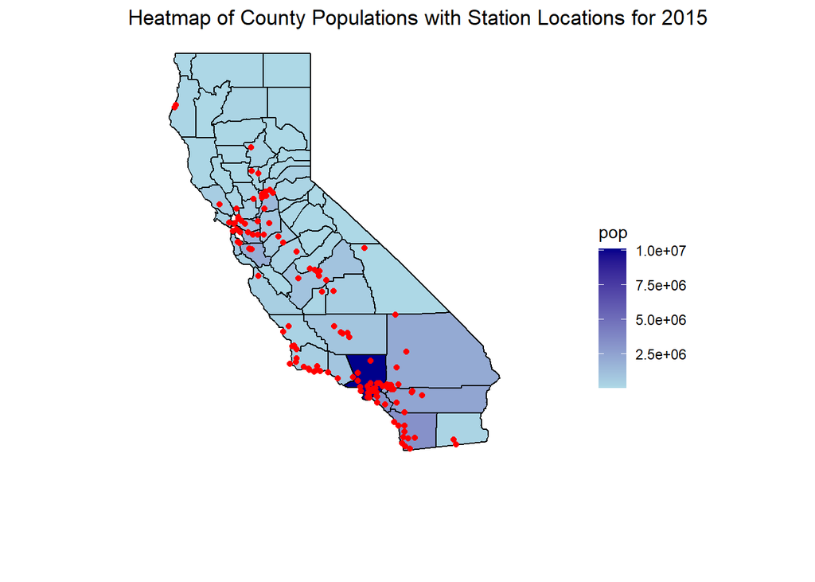

```r
pollutants1_2015 = readRDS("C:/Users/jeffr/Desktop/Spatiotemporal + Causal Inference/Wildfire Paper 1 Code/EPA data/Raw/pollutants1_2015_8.17.RData")
pollutants2_2015 = readRDS("C:/Users/jeffr/Desktop/Spatiotemporal + Causal Inference/Wildfire Paper 1 Code/EPA data/Raw/pollutants2_2015_8.17.RData")

stationlats = c(unique(pollutants1_2015$latitude),unique(pollutants2_2015$latitude))
stationlongs = c(unique(pollutants1_2015$longitude),unique(pollutants2_2015$longitude))

station_points = data.frame(stationlats,stationlongs)

#Plot
gg_pop_stations <- ggplot() +
  geom_polygon(data = merged_data, aes(x = long, y = lat, group = group, fill = pop),
               color = "black") +
  coord_fixed(ratio = 1.3, xlim = c(-125, -112), ylim = c(30, 42)) +
  theme_void() +
  labs(title = "Heatmap of County Populations with Station Locations for 2015") +
  scale_fill_gradient(low = "lightblue", high = "darkblue")

# Add points
gg_pop_stations <- gg_pop_stations +
  geom_point(data = station_points, aes(x = stationlongs, y = stationlats),
             color = "red", size = 1.5)

print(gg_pop_stations)
```

# Downloading and aggregating air quality data using direct API calls

Given a set of 5-20 monitoring stations for each county, we loop through its station codes (for each year 2014-2019) and query using the EPA’s AQS function. This function only allows you to query a maximum of 4 parameters at once for a single year, so two calls to the function have to be made for each year (4 and 3).

(BELOW SHOWS IT BEING DONE FOR 2019)

END GOAL FINAL FORM: ONE BIG DATAFRAME (ALL POLLUTANTS ALL YEARS TOGETHER, USE FILTER TO SEPARATE)

```r
# 1 - Lead, 2 - Carbon monoxide (CO), 3 - Sulfure dioxide (SO2), 4 - Nitrogen dioxide (NO2)
# 5 - Ozone (O3), 6 - Total PM10, 7 - PM2.5

stations2019x = rbind(Lead_stations[[6]],CO_stations[[6]],
             SO2_stations[[6]],NO2_stations[[6]])
stations2019y = rbind(O3_stations[[6]],PM10_stations[[6]],PM2.5_stations[[6]])

sitenums2019x = stations2019x %>% select(county_code,site_number) %>% unique() #198 stations
sitenums2019y = stations2019y %>% select(county_code,site_number) %>% unique() #178 stations


#Trying EPA R Package query (took 15 + 20 min!) gives us a dataframe
ccodes = sitenums2019y$county_code
snums = sitenums2019y$site_number
str1 = "2019-01-01"
str2 = "2019-12-31"

pollutants1_2019 = aqs_dailysummary_by_site(parameter = c("14129","42101","42401","42602"),bdate = as.Date(str1),edate = as.Date(str2),stateFIPS = "06",countycode = ccodes,sitenum = snums)

pollutants2_2019 = aqs_dailysummary_by_site(parameter = c("44201","81102","88101"),bdate = as.Date(str1),edate = as.Date(str2),stateFIPS = "06",countycode = ccodes,sitenum = snums)

###SAVE LIST LOCALLY
saveRDS(pollutants2_2019,file = "C:/Users/jeffr/Desktop/Spatiotemporal + Causal Inference/Wildfire Paper 1 Code/EPA data/Raw/pollutants2_2019_8.18.RData")
```

After querying the raw data for each pollutant and each year, we want to go through it and remove any data from stations that have “bad” data. The standards that I set (for now) are that for a given year, a station should have at least 240 of the 365 days included for a year of data. Additionally, I applied a Hampel filter to identify outliers and if there are more than 14 consecutive outliers in the data i.e., days in a row with measurements that are abnormal, I considered the data from that station to not be suitable for inclusion in the final dataset.

NOTE: the daily values reported in the raw dataset are actually daily averages from periodic measurements made by the station throughout the day

After data from so called “bad” stations were removed, another function is applied which aggregates the daily observations into a monthly median The raw data is in the form of a single dataframe, which is fed into the important function raw_transform(). This function uses several functions to create a list of dataframes, one for each county, which represent the monthly median measurements for a certain pollutant in a given county in a given year.

QUALITY CHECK FUNCTION FOR STATION DATA: WANT TO ADDRESS OUTLIERS, MISSINGNESS

```r
#Given a dataset like CO2016 (list of 1000ish stations), check for 2/3 missing data and for strings of outliers (14 in a row)

station_quality_check = function(station_data){
  l = length(station_data)
  badindex = c()
  consecutive_outliers = list()

  for (i in 1:l){
    aqi = station_data[[i]]$aqi
    pollutant_level = station_data[[i]]$arithmetic_mean

    #check for outliers in AQI
    median.aqi = median(na.omit(aqi))
    mad.aqi = mad(na.omit(aqi))

    min.aqi = median.aqi-(3*mad.aqi)
    max.aqi = median.aqi+(3*mad.aqi)

    outliers.aqi = which(aqi < min.aqi | aqi > max.aqi)

    result.aqi = rle(diff(outliers.aqi))


    #check for outliers in pollutant measure
    median.pollutant = median(na.omit(pollutant_level))
    mad.pollutant = mad(na.omit(pollutant_level))

    min.pollutant = median.pollutant-(3*mad.pollutant)
    max.pollutant = median.pollutant+(3*mad.pollutant)

    outliers.pollutant = which(pollutant_level < min.pollutant | pollutant_level > max.pollutant)

    result.pollutants = rle(diff(outliers.pollutant))


    if (nrow(station_data[[i]]) < 240){
      badindex = c(badindex,i)
    }

    else if (any(result.aqi$lengths >= 14 & result.aqi$values == 1) == TRUE){
      badindex = c(badindex,i)
    }

    else if (any(result.pollutants$lengths >= 14 & result.pollutants$values == 1) == TRUE){
      badindex = c(badindex,i)
    }

    consecutive_outliers[[i]] = c("AQI",outliers.aqi,"POLLUTANTS",outliers.pollutant)
  }

  bad_list = list(badindex,consecutive_outliers)

  return(bad_list)
}


#Test on CO2016 and CO2017
# station_quality_check(CO2016) #returns 61 "bad stations" out of 1230
#
# removeidx = station_quality_check(SO22017)[[1]] #returns 715 out of 1056 "bad stations"
#
# test = SO22017[- removeidx]
```

FUNCTION THAT AGGREGATES DAILY DATA INTO MONTHYLY MEDIANS

```r
monthly_agg = function(pollutantdata){
  #Aggregating all the station data at once
  date = ymd(pollutantdata$date_local)
  df2 <- pollutantdata                                   # Duplicate data
  df2$year_month <- floor_date(date,"month")  # Create year-month column
  df3 = df2 %>% select(county,site_number,arithmetic_mean,aqi,year_month) %>% as.data.frame()

  df3$arithmetic_mean = as.numeric(df3$arithmetic_mean)
  df3$aqi[which(df3$aqi == "NULL")] = NA
  df3$aqi = as.numeric(df3$aqi)

  df.agg = df3 %>% group_by(year_month) %>% dplyr::summarize(arithmetic_mean = median(na.omit(arithmetic_mean)),aqi = median(na.omit(aqi))) %>% as.data.frame()

  return(df.agg)
}
```

IMPORTANT FUNCTION: TRANSFORMING RAW DATA TO FINAL FORM

```r
# Group 1: 14129 - Lead, 421012 - Carbon monoxide (CO), 42401 - Sulfure dioxide (SO2), 42602 - Nitrogen dioxide (NO2)
# Group 2: 44201 - Ozone (O3), 81102 - Total PM10, 88101 - PM2.5

raw_transform = function(rawdata,reference_list,standard){

  ###SEPARATE DF INTO A LIST OF DFs

  matched_list = list()

  if(missing(standard)){
    for (i in 1:nrow(reference_list)){
    data = rawdata %>% filter(county_code == reference_list$county_code[i], site_number == reference_list$site_number[i])

    matched_list[[i]] = data
    }
  } else {
      for (i in 1:nrow(reference_list)){
      data = rawdata %>% filter(county_code == reference_list$county_code[i], site_number == reference_list$site_number[i],pollutant_standard == standard)

      matched_list[[i]] = data
    }
  }

  names(matched_list) = reference_list$measuring_county

  ###STATION QUALITY CHECK

  removeidx = station_quality_check(matched_list)[[1]]
  good_matched_list = matched_list[- removeidx]

  #Convert list back into one big dataframe
  temp = as.data.frame(do.call(rbind, good_matched_list)) #TOO MANY ROWS RIGHT?
  good_df = unique.data.frame(temp)


  ###MAKE A LIST OF COMBINED STATION DATA FOR EACH COUNTY
  mid_list = list()

  for (i in unique(reference_list$measuring_county)){

    df_new = data.frame(good_df[1,])
    subset = reference_list %>% filter(measuring_county == i) %>% select(county_code,site_number)

    for (j in 1:nrow(subset)){
      pull = good_df %>% filter(county_code == reference_list$county_code[j], site_number == reference_list$site_number[j])

      df_new = rbind(df_new,pull)
    }

    df_new = df_new[-1,]
    mid_list[[i]] = df_new
  }

  ###AGGREGATE DAILY DATA TO MONTHLY FOR EACH COUNTY

  final_list = lapply(mid_list,monthly_agg)

  return(final_list)
}
```

When assembling final datasets, note that certain pollutant standards are used bc they have values for AQI… the ones I used were:

Lead: Lead 3-Month 2009 ?? Has all NAs for AQI

CO: CO 8-hour 1971

SO2: SO2 1-hour 2010

NO2: NO2 1-hour 2010

O3: Ozone 8-hour 2015 ; sample duration should be 8 HR

PM10: PM10 24-hour 2006

PM2.5: PM25 24-hour 2012

APPLY RAW TRANSFORM FUNCTION TO ALL POLLUTANTS FOR ALL YEARS (BELOW SHOWS IT BEING DONE FOR 2019)

```r
#Load raw data
pollutants1_2019 = readRDS("C:/Users/jeffr/Desktop/Spatiotemporal + Causal Inference/Wildfire Paper 1 Code/EPA data/Raw/pollutants1_2019_8.18.RData")
pollutants2_2019 = readRDS("C:/Users/jeffr/Desktop/Spatiotemporal + Causal Inference/Wildfire Paper 1 Code/EPA data/Raw/pollutants2_2019_8.18.RData")

Lead2019 = pollutants1_2019 %>% filter(parameter_code == "14129")
CO2019 = pollutants1_2019 %>% filter(parameter_code == "42101")
SO22019 = pollutants1_2019 %>% filter(parameter_code == "42401")
NO22019 = pollutants1_2019 %>% filter(parameter_code == "42602")
O32019 = pollutants2_2019 %>% filter(parameter_code == "44201")
PM102019 = pollutants2_2019 %>% filter(parameter_code == "81102")
PM2.52019 = pollutants2_2019 %>% filter(parameter_code == "88101")


Lead2019_final = raw_transform(rawdata = Lead2019,reference_list = Lead_stations[[6]],standard = "Lead 3-Month 2009")

CO2019_final = raw_transform(rawdata = CO2019,reference_list = CO_stations[[6]],standard = "CO 8-hour 1971")

SO22019_final = raw_transform(rawdata = SO22019,reference_list = SO2_stations[[6]],standard = "SO2 1-hour 2010")

NO22019_final = raw_transform(rawdata = NO22019,reference_list = NO2_stations[[6]],standard = "NO2 1-hour 2010")

O32019_final = raw_transform(rawdata = O32019,reference_list = O3_stations[[6]],standard = "Ozone 8-hour 2015")

PM102019_final = raw_transform(rawdata = PM102019,reference_list = PM10_stations[[6]],standard = "PM10 24-hour 2006")

PM2.52019_final = raw_transform(rawdata = PM2.52019,reference_list = PM2.5_stations[[6]],standard = "PM25 24-hour 2012")
```

COMBINING EACH POLLUTANTS DATASET INTO A SINGLE DATAFRAME FOR THE YEAR (BELOW SHOWS IT BEING DONE FOR 2019)

```r
###Combine final data into one dataframe for 2014
test1 = as.data.frame(do.call(rbind, Lead2019_final))
test1 = cbind(test1,rep(pollutants$parametercodes.code[1],nrow(test1))) #maybe change parameter codes to 1-7?
colnames(test1) = c("Year-Month","Value","AQI","Pollutant")

test2 = as.data.frame(do.call(rbind, CO2019_final))
test2 = cbind(test2,rep(pollutants$parametercodes.code[2],nrow(test2))) #maybe change parameter codes to 1-7?
colnames(test2) = c("Year-Month","Value","AQI","Pollutant")

test3 = as.data.frame(do.call(rbind, SO22019_final))
test3 = cbind(test3,rep(pollutants$parametercodes.code[3],nrow(test3))) #maybe change parameter codes to 1-7?
colnames(test3) = c("Year-Month","Value","AQI","Pollutant")

test4 = as.data.frame(do.call(rbind, NO22019_final))
test4 = cbind(test4,rep(pollutants$parametercodes.code[4],nrow(test4))) #maybe change parameter codes to 1-7?
colnames(test4) = c("Year-Month","Value","AQI","Pollutant")

test5 = as.data.frame(do.call(rbind, O32019_final))
test5 = cbind(test5,rep(pollutants$parametercodes.code[5],nrow(test5))) #maybe change parameter codes to 1-7?
colnames(test5) = c("Year-Month","Value","AQI","Pollutant")

test6 = as.data.frame(do.call(rbind, PM102019_final))
test6 = cbind(test6,rep(pollutants$parametercodes.code[6],nrow(test6))) #maybe change parameter codes to 1-7?
colnames(test6) = c("Year-Month","Value","AQI","Pollutant")

test7 = as.data.frame(do.call(rbind, PM2.52019_final))
test7 = cbind(test7,rep(pollutants$parametercodes.code[7],nrow(test7))) #maybe change parameter codes to 1-7?
colnames(test7) = c("Year-Month","Value","AQI","Pollutant")

#Combine each pollutant dataset into one big dataset for the year
final_data19 = rbind(test1,test2,test3,test4,test5,test6,test7)

###SAVE FINAL DATASET LOCALLY
saveRDS(final_data19,file = "C:/Users/jeffr/Desktop/Spatiotemporal + Causal Inference/Wildfire Paper 1 Code/EPA data/Aggregated/final_data19_9.1.RData")
```

HAVE TO CLEAN DATA BEFORE FINALIZING:

Having combined the monthly medians for every county for a single year for each pollutant into a single dataframe, one final cleaning step must be performed before putting each years’ data together. The AQI value that is in each row corresponds to the AQI standardized measurement for that specific pollutant. Each pollutant has a different standardizing equation, but once they are all standardized as they are in the dataset and they can be compared against each other. The reported AQI measurement for a given day is just the maximum of the AQI values corresponding to each of the 7 pollutants. So the maximum AQI value (among 6 values bc Lead observations never have AQI values) was found for each month and that value was set as the actual AQI value for that month in all corresponding rows.

FIND MAX AQI (AMONG THE 7 POLLUTANTS) FOR EACH MONTH -> SET AS ACTUAL AQI FOR THAT MONTH

(BELOW SHOWS IT BEING DONE FOR 2019)

```r
#Do for each year
months = c("01","02","03","04","05","06","07","08","09","10","11","12")

###Do for each year
for (i in 1:58){
  idx1 = which(stringr::str_starts(rownames(final_data19), counties[i]))
  subset1 = final_data19[idx1,]
  subset1$`Year-Month`= as.Date(subset1$`Year-Month`)

  for (j in months){
  #Filter by county and date
    date = paste0("2019-",j,"-01")
    date = as.Date(date)
    subset2 = subset1 %>% filter(`Year-Month` == as.Date(date))

    trueAQI = max(na.omit(subset2$AQI))

    idx2 = which(subset1$`Year-Month` == date)
    subset1$AQI[idx2] = trueAQI
  }

  final_data19[idx1,] = subset1
}

###SAVE FINAL DATASET LOCALLY
saveRDS(final_data19,file = "C:/Users/jeffr/Desktop/Spatiotemporal + Causal Inference/Wildfire Paper 1 Code/EPA data/Aggregated/final_data19_9.1.RData")
```

COMBINING EACH YEARS DATASET INTO ONE BIG TIDY DATAFRAME FOR AIR QUALITY COVARIATES

FILL IN YOUR OWN FILE DIRECTORIES HERE! START WORKING W ACTUAL EPA DATA FROM HERE ON

```r
final_data14 = readRDS("C:/Users/jeffr/Desktop/Spatiotemporal + Causal Inference/Wildfire Paper 1 Code/EPA data/Aggregated/final_data14_9.1.RData")
final_data15 = readRDS("C:/Users/jeffr/Desktop/Spatiotemporal + Causal Inference/Wildfire Paper 1 Code/EPA data/Aggregated/final_data15_9.1.RData")
final_data16 = readRDS("C:/Users/jeffr/Desktop/Spatiotemporal + Causal Inference/Wildfire Paper 1 Code/EPA data/Aggregated/final_data16_9.1.RData")
final_data17 = readRDS("C:/Users/jeffr/Desktop/Spatiotemporal + Causal Inference/Wildfire Paper 1 Code/EPA data/Aggregated/final_data17_9.1.RData")
final_data18 = readRDS("C:/Users/jeffr/Desktop/Spatiotemporal + Causal Inference/Wildfire Paper 1 Code/EPA data/Aggregated/final_data18_9.1.RData")
final_data19 = readRDS("C:/Users/jeffr/Desktop/Spatiotemporal + Causal Inference/Wildfire Paper 1 Code/EPA data/Aggregated/final_data19_9.1.RData")

final_EPA_data = rbind(final_data14,final_data15,final_data16,final_data17,
                       final_data18,final_data19)
saveRDS(final_EPA_data,file = "C:/Users/jeffr/Desktop/Spatiotemporal + Causal Inference/Wildfire Paper 1 Code/EPA data/Final/final_EPA_data_9.1.RData")


final_EPA_data = readRDS("C:/Users/jeffr/Desktop/Spatiotemporal + Causal Inference/Wildfire Paper 1 Code/EPA data/Final/final_EPA_data_9.1.RData")
head(final_EPA_data)
```

|  | Year-Month | Value | AQI | Pollutant |
| --- | --- | --- | --- | --- |
| Alameda.1 | 2014-01-01 | 0.0500 | 60 | 14129 |
| Alameda.2 | 2014-02-01 | 0.0520 | 28 | 14129 |
| Alameda.3 | 2014-03-01 | 0.0655 | 34 | 14129 |
| Alameda.4 | 2014-04-01 | 0.0360 | 40 | 14129 |
| Alameda.5 | 2014-05-01 | 0.0300 | 38 | 14129 |
| Alameda.6 | 2014-06-01 | 0.0230 | 37 | 14129 |

# Adding cluster labels to the EPA data and aggregating based on clusters

Once the EPA data is in the correct format (one big dataframe) at the county level, we now need to aggregate it to the cluster level according to the SKATER cluster labels from before. A population weighted mean was used to aggregate here as well, MAY OR MAY NOT BE APPROPRIATE?

```r
Cluster = rep(1,length(final_EPA_data))
final_EPA_agg_data = cbind(final_EPA_data,Cluster)

for (i in 1:58){
  idx = which(stringr::str_starts(rownames(final_EPA_agg_data), counties[i]))
  final_EPA_agg_data$Cluster[idx] = clusterlabels$Cluster[i]
}

Time = c(rep(c(1:12),58),rep(13:24,58),rep(25:36,58),rep(37:48,58),rep(49:60,58),rep(61:72,58))
Time = rep(Time,7)
final_EPA_agg_data = cbind(Time,final_EPA_agg_data)
```

AGGREGATE CLUSTER DATA AND COMBINE INTO ONE DATAFRAME

```r
countypops = CA_data %>% filter(Year > 2013) %>% select(Total_Pop,County,Year) %>% unique()
countypops = cbind(countypops,Cluster = rep(clusterlabels$Cluster,each=6))
countypops$County = rep(counties,each=6)

temp_EPA_agg_data = data.frame(final_EPA_agg_data[1,-2])
num_clus = length(unique(clusterlabels$Cluster))

for (k in 1:num_clus){

  EPA_clus_k = data.frame(final_EPA_agg_data[1,-2])

  for (i in pollutants$parametercodes.code){
  pollutant_data = final_EPA_agg_data %>% filter(Pollutant == i)

  cluster_data = pollutant_data %>% filter(Cluster == k)
  year = 2014

  for(j in 1:72){
    cluster_data_j = cluster_data %>% filter(Time == j)
    cluster_counties = countypops %>% filter(Cluster == k,Year == year)

    pops = countypops %>% filter(Year == year,Cluster == k) %>% select(Total_Pop)
    cluster.pop = sum(pops)
    cluster.popweights = pops/cluster.pop

    value_wmean = weighted.mean(cluster_data_j$Value,cluster.popweights$Total_Pop)
    aqi_wmean = weighted.mean(cluster_data_j$AQI,cluster.popweights$Total_Pop)
    insert = data.frame(Time = j,value_wmean,aqi_wmean,
                        Pollutant = i,Cluster = k)
    colnames(insert) = colnames(EPA_clus_k)

    EPA_clus_k = rbind(EPA_clus_k,insert)

    if ((j>12) & (j<25)){
      year = 2015
    }

    else if ((j>24) & (j<37)){
      year = 2016
    }

    else if ((j>36) & (j<49)){
      year = 2017
    }

    else if ((j>48) & (j<61)){
      year = 2018
    }

    else if ((j>60) & (j<73)){
      year = 2019
    }

    else{
      year = 2014
    }
  }
  }

  EPA_clus_k = EPA_clus_k[-1,]
  trueAQI = EPA_clus_k$AQI[1:72]
  trueAQI = rep(trueAQI,7)
  EPA_clus_k$AQI = trueAQI
  rownames(EPA_clus_k) = NULL

  temp_EPA_agg_data = rbind(temp_EPA_agg_data,EPA_clus_k)

}

final_EPA_agg_data = temp_EPA_agg_data[-1,]

saveRDS(final_EPA_agg_data,file = "C:/Users/jeffr/Desktop/Spatiotemporal + Causal Inference/Wildfire Paper 1 Code/EPA data/Final/final_8.1_EPA_agg_data_10.26.RData")

final_EPA_agg_data = readRDS("C:/Users/jeffr/Desktop/Spatiotemporal + Causal Inference/Wildfire Paper 1 Code/EPA data/Final/final_8.1_EPA_agg_data_10.26.RData")

head(final_EPA_agg_data)
```

|  | Time | Value | AQI | Pollutant | Cluster |
| --- | --- | --- | --- | --- | --- |
| 1 | 1 | 0.0500 | 59.68775 | 14129 | 1 |
| 2 | 2 | 0.0520 | 28.10665 | 14129 | 1 |
| 3 | 3 | 0.0655 | 34.82019 | 14129 | 1 |
| 4 | 4 | 0.0360 | 40.81072 | 14129 | 1 |
| 5 | 5 | 0.0300 | 39.09718 | 14129 | 1 |
| 6 | 6 | 0.0230 | 35.62195 | 14129 | 1 |

## Calculating gram matrix K from EPA data

Once the EPA air quality data is queried and structured correctly, we can now calculate the gram matrix K which will characterize the dependence structure of air quality (across 7 different pollutants and AQI) over time. This is done by calculating the squared difference between all of the observations at two different time points e.g. 64 observations for Jan 2014 compared with the 64 observations for Feb 2014. The resulting matrix is 72x72, as it should since there are 72 months of observations (2014-2019). The length and scale hyperparameters have yet to be rigorously set at this juncture.

NEED TO DO HYPERPARAMETER LEARNING TO SET LENGTH AND SCALE HYPERPARAMETERS HERE

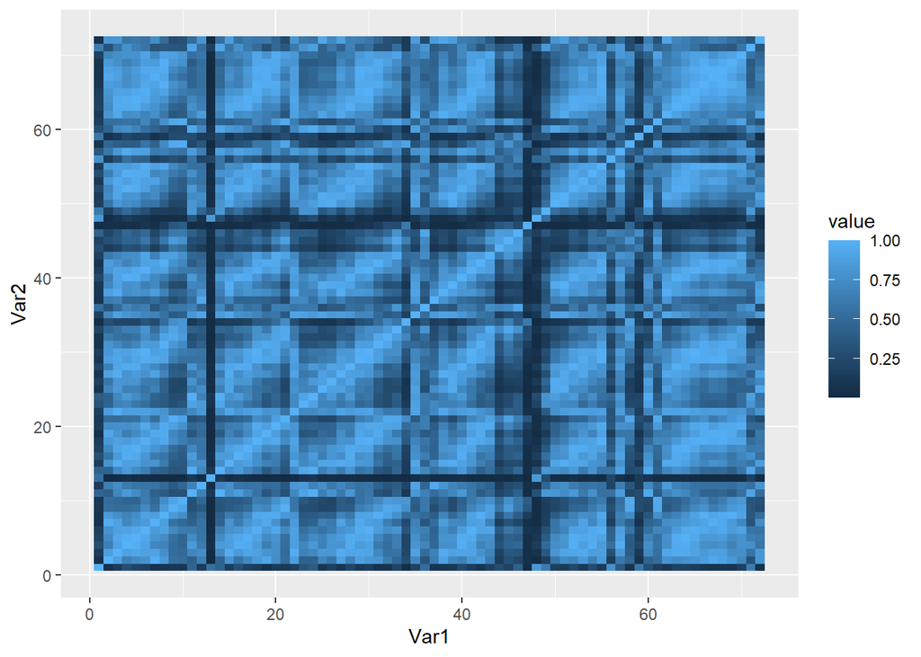

```r
K_clus = matrix(0,nrow=72,ncol=72)
i = 1
j = 1
sigma = 5

for(t1 in unique(final_EPA_agg_data$Time)){
  for (t2 in unique(final_EPA_agg_data$Time)){
    A = final_EPA_agg_data %>% filter(Time == t1)
    B = final_EPA_agg_data %>% filter(Time == t2)
    AQIa = unique(A$AQI)
    AQIb = unique(B$AQI)

    ABtest = c((A$Value-B$Value)^2,(AQIa-AQIb)^2) #8 clusters * 8 measurements
    K_clus[i,j] = exp(-mean(ABtest) / (2*sigma^2))

    j = j+1
  }

  j = 1
  i = i+1
}

#Heatmap of resulting K
library(reshape2)
melted_cormat <- melt(K_clus)
ggplot(data = melted_cormat, aes(x=Var1, y=Var2, fill=value)) +
  geom_tile()
```

## Cleaning and aggregating CalViDa mortality data

# Imputing “< 11” values in data with EM algorithm

In the mortality dataset obtained from Cal-ViDa, all of the cells with small values i.e., less than 10 but not equal to 0, were censored. So in order to avoid using a truncated Poisson distribution, we decided to impute these censored values with an EM algorithm which is described below:

For each county and month, we assume that the number of mortality follows a Poisson distribution with rate $\lambda_i = X_i \beta$. We will estimate this rate using a Poisson regression model.

For observed counts, we know $P(Y_i = y_i) = \frac{\lambda_i^{y_i}e^{-\lambda_i}}{y_i!}$ for $1 \leq i \leq n_{obs}$ where $n_{obs}$ are the number of observations that are not censored out of the total observations $N$.

For censored counts, we do not observe $Z_i$, but we know that $Z_i \in [1,10]$. So we can say that $P(Z_i \in [1,10]) = \sum_{j=1}^{10} \frac{\lambda_i^{j}e^{-\lambda_i}}{j!}$ for $n_{obs}+1 \leq i \leq N$.

**Thus, the marginal likelihood of our observed mortality data can be written as:**

$L(\beta ; Y_1,...,Y_{n_{obs}},W_{n_{obs}+1},...,W_N) = \Pi_{i=1}^{n_{obs}} \frac{\lambda_i^{y_i}e^{-\lambda_i}}{y_i!} * \Pi_{i=n_{obs}+1}^{N} \sum_{j=1}^{10} (\frac{\lambda_i^{j}e^{-\lambda_i}}{j!})$ which equals $\Pi_{i=1}^{n_{obs}} \frac{(X_i \beta)_i^{y_i}e^{-X_i \beta}}{y_i!} * \Pi_{i=n_{obs}+1}^{N} \sum_{j=1}^{10} (\frac{(X_i \beta)^{j}e^{-X_i \beta}}{j!})$

Given the nature of this complicated marginal likelihood, we will use the EM algorithm to get maximum likelihood estimates (MLEs) of the unknown values $\beta$.

The full likelihood of $\overrightarrow Y,\overrightarrow W,\overrightarrow Z$ is given by:

$L(\beta;\overrightarrow Y,\overrightarrow W,\overrightarrow Z) = p(\overrightarrow Y,\overrightarrow Z | \beta) = \Pi_{i=1}^{n_{obs}} \frac{(X_i \beta)_i^{Y_i}e^{-X_i \beta}}{Y_i!} * \Pi_{i=n_{obs}+1}^{N} (\frac{(X_i \beta)^{Z_i}e^{-X_i \beta}}{Z_i!})$ where $1 \leq Z_i \leq 10$ and $P(\overrightarrow W | \overrightarrow Z) = 1$

The corresponding log likelihood is given by:

$log \; L(\beta,\overrightarrow Y,\overrightarrow W,\overrightarrow Z) = \sum_{i=1}^{n_{obs}} [Y_i log(X_i \beta) - X_i \beta - log(Y_i!)] + \sum_{i=n_{obs}+1}^N [Z_i log(X_i \beta) - X_i \beta - log(Z_i!)]$

In other words, $(Z_i | \overrightarrow W_i,\beta^{(t)}) \sim TruncPois(X_i \beta)$ for $i \geq n_{obs}+1$

**E-step: Finding the expected value of the log likelihood function of** $\beta$

Let $Q(\beta | \beta^{(t)}) := E_{Z \sim (. | \overrightarrow Y,\overrightarrow W,\beta^{(t)})} [log \; p(\overrightarrow Y,\overrightarrow Z | \beta))]$

i.e. the expected value of the log likelihood function of $\beta$, with respect to the current conditional distribution of $Z$ $p(Z | \overrightarrow Y,\overrightarrow W,\beta^{(t)})$

So in our case,

$Q(\beta | \beta^{(t)}) = \sum_{i=1}^{n_{obs}} [Y_i log(X_i \beta) - X_i \beta - log(Y_i!)] + \sum_{i=n_{obs}+1}^N [E[Z_i | \overrightarrow W_i,\beta^{(t)})] \; log(X_i \beta) - X_i \beta - E[log(Z_i!) | \overrightarrow W_i,\beta^{(t)}]]$

**M-step: Finding the parameters that maximize** $Q(\beta | \beta^{(t)})$

$\beta^{(t+1)} = arg \; max_{\beta} Q(\beta | \beta^{(t)})$

So in our case, we need to maximize $Q(\beta | \beta^{(t)})$.

$\beta^{(t+1)} = arg \; max_{\beta} \sum_{i=1}^{n_{obs}} [Y_i log(X_i \beta) - X_i \beta - log(Y_i!)] + \sum_{i=n_{obs}+1}^N [E[Z_i | \overrightarrow W_i,\beta^{(t)})] \; log(X_i \beta) - X_i \beta - E[log(Z_i! ) | \overrightarrow W_i,\beta^{(t)}]]$

This is equivalent to fitting a Poisson regression in which the outcomes are $Y_i$ for $i \leq n_{obs}$ and censored values $Z_i$ by $E[Z_i | \overrightarrow W,\beta^{(t)})]$ for $i \geq n_{obs}+1$.

**We coded this algorithm as follows:**

First, we needed to get an initial estimate of our $\beta$ coefficients in our Poisson regression model. We included age group, county of death, cause of death (either influenza+pneumonia OR chronic lower respiratory disease), and month of death as covariates.

To do this, we needed to perform an initial imputation to get a complete dataset to fit a model on. We decided to do this by making a crude estimation of the rate per 100,000 people $\lambda_i$. To do this, we calculated a population weighted mean of the number of deaths across all ages and months. However, we only had observed populations at the county level, not for each specific age group included in the mortality data. So using census data which told us the approximate populations for specific age groups (for all of California), we were able to calculate approximate population sizes for each of the age categories included in the mortality data. See death_byage2 for reference. Then using the ratio of a given county’s population relative to the entire population of California, we were able to calculate approximations for the population size of each age group for each county in our mortality dataset. These served as the weights for our population weighted average of the rate of respiratory deaths in California.

```r
population_age = read_xlsx("Population Categories.xlsx")
## New names:
## • `` -> `...2`
## • `` -> `...3`
## • `` -> `...4`
## • `` -> `...5`
## • `` -> `...6`
## • `` -> `...7`
## • `` -> `...8`
## • `` -> `...9`
## • `` -> `...10`
## • `` -> `...11`
## • `` -> `...12`
## • `` -> `...13`
#head(population_age)

population_age = population_age[-(1:5),2]
population_age$...2 = as.numeric(population_age$...2)

#split under 5 category into < 1 and 1-4 years old
less1 = floor(population_age$...2[1]*0.2)
onefour = floor(population_age$...2[1]*0.8)
death_byage = population_age$...2[-1]
death_byage = c(less1,onefour,death_byage)
death_byage = death_byage[1:19]

death_byage2 = death_byage[1:2]
idx = seq(from = 3, to = 17, by = 2)
for (i in idx){
  death_byage2 = c(death_byage2,(death_byage[i]+death_byage[i+1]))
}
death_byage2 = c(death_byage2,death_byage[19])


age_groups = unique(mortality$Age)
death_byage2 = data.frame(cbind(age_groups,death_byage2))
colnames(death_byage2) = c("Age_Group","Population_by_Age")
death_byage2$Population_by_Age = as.numeric(death_byage2$Population_by_Age)
#head(death_byage2)

#2010-2019 population data for CA
USpops = read.csv("CA_census_pops1019.csv")
CApops = USpops %>% filter(STNAME == "California") %>% select(CTYNAME,POPESTIMATE2019)
counties = countycodes$value_represented #from EPA data file

weights = CApops[(2:59),2]
weights = weights/CApops[1,2]

groups = unique(mortality$Age)
step1 = 1
step2 = 1

for (i in counties){
  for (j in groups){
    idx = which(mortality$Age == j & mortality$County_of_Death == i)
    mortality$Population[idx] = ceiling(death_byage2$Population[step1]*weights[step2])
    step1 = step1+1
  }
  step1 = 1
  step2 = step2+1
}

mortality$logpop = log(mortality$Population)

censored_idx = which(mortality$Total_Deaths == "<11")
censorTF = mortality$Total_Deaths == "<11"
mortality = cbind(mortality,censorTF)
#head(mortality)
```

GETTING INITIAL GUESS FOR LAMBDA: AVG DEATHS (PER 100K PEOPLE) PER MONTH FOR ONE COUNTY

```r
uncensored_mortality = mortality %>% filter(censorTF == FALSE) %>% select(Total_Deaths,Population)
uncensored_mortality$Total_Deaths = as.numeric(uncensored_mortality$Total_Deaths)

theta = mean(uncensored_mortality$Total_Deaths*100000/uncensored_mortality$Population)
```

By using all the data, I obtained a crude initial guess for $\lambda$ of about 1.09. Using this initial estimate $\lambda$, we calculated the expected value for each $Z_i$ to get an initial imputed dataset. This dataset will be used to estimate a Poisson regression model which will give us our initial value for our actual parameters of interest $\beta$.

FUNCTION FOR IMPUTING CENSORED VALUE BASED ON EXPECTATION GIVEN LAMBDA

```r
impute_small_values = function(lambda){
  x = 1:10
  p = dpois(x,lambda)

  value = sum(x*p)/sum(p)
  return(value)
}
```

INITIAL IMPUTATION:

```r
mortality2 = mortality
mortality2$Total_Deaths[censored_idx] = 0.01
mortality2$Total_Deaths = as.numeric(mortality2$Total_Deaths)

for (i in censored_idx){
  lambda = theta*mortality2$Population[i] / 100000
  deaths = impute_small_values(lambda)

  mortality2$Total_Deaths[i] = floor(deaths)
}
```

INITIAL REGRESSION MODELS:

```r
mortality2$Age = factor(mortality2$Age)
mortality2$Cause_of_Death = factor(mortality2$Cause_of_Death)
mortality2$Month = factor(mortality2$Month)

pois_reg = glm(Total_Deaths ~ Age + Cause_of_Death + Month + offset(logpop), family = "poisson", data = mortality2)
ZIP_reg = zeroinfl(Total_Deaths ~ Age + Cause_of_Death + Month + offset(logpop) | 1, data = mortality2, dist = "poisson", link = "logit")

vec0 = coef(pois_reg)
# vec0 = coef(ZIP_reg)

summary(pois_reg)
```

```
##
## Call:
## glm(formula = Total_Deaths ~ Age + Cause_of_Death + Month + offset(logpop),
##     family = "poisson", data = mortality2)
##
## Deviance Residuals:
##     Min       1Q   Median       3Q      Max
## -5.4203  -0.5217  -0.2134  -0.0656  14.4584
##
## Coefficients:
##                                         Estimate Std. Error  z value Pr(>|z|)
## (Intercept)                           -13.674687   0.086503 -158.083  < 2e-16
## Age15 - 24 years                        0.495983   0.094684    5.238 1.62e-07
## Age25 - 34 years                        1.014002   0.090752   11.173  < 2e-16
## Age35 - 44 years                        1.609338   0.088961   18.090  < 2e-16
## Age45 - 54 years                        2.301830   0.087633   26.267  < 2e-16
## Age5 - 14 years                         0.147756   0.098656    1.498    0.134
## Age55 - 64 years                        3.064960   0.086830   35.299  < 2e-16
## Age65 - 74 years                        4.113175   0.086443   47.583  < 2e-16
## Age75 - 84 years                        5.281266   0.086304   61.194  < 2e-16
## Age85 years and over                    6.427722   0.086240   74.533  < 2e-16
## AgeLess than 1 year                     0.875421   0.140545    6.229 4.70e-10
## Cause_of_DeathInfluenza and pneumonia  -0.745146   0.007174 -103.873  < 2e-16
## Month2                                 -0.253244   0.013639  -18.568  < 2e-16
## Month3                                 -0.251047   0.013630  -18.418  < 2e-16
## Month4                                 -0.450697   0.014453  -31.184  < 2e-16
## Month5                                 -0.522766   0.014779  -35.373  < 2e-16
## Month6                                 -0.646842   0.015379  -42.059  < 2e-16
## Month7                                 -0.661856   0.015456  -42.823  < 2e-16
## Month8                                 -0.709788   0.015704  -45.198  < 2e-16
## Month9                                 -0.738548   0.016241  -45.474  < 2e-16
## Month10                                -0.646717   0.016357  -39.538  < 2e-16
## Month11                                -0.616267   0.016185  -38.076  < 2e-16
## Month12                                -0.345668   0.014803  -23.351  < 2e-16
##
## (Intercept)                           ***
## Age15 - 24 years                      ***
## Age25 - 34 years                      ***
## Age35 - 44 years                      ***
## Age45 - 54 years                      ***
```

[output cut: 13 more lines]

```
## Month8                                ***
## Month9                                ***
## Month10                               ***
## Month11                               ***
## Month12                               ***
## ---
## Signif. codes:  0 '***' 0.001 '**' 0.01 '*' 0.05 '.' 0.1 ' ' 1
##
## (Dispersion parameter for poisson family taken to be 1)
##
##     Null deviance: 367007  on 87493  degrees of freedom
## Residual deviance:  71214  on 87471  degrees of freedom
## AIC: 121347
##
## Number of Fisher Scoring iterations: 8
```

```r
# summary(ZIP_reg)
```

Now that we have initialized our parameters, $\beta^{(0)}$, we can proceed with the EM algorithm until our parameters (the coefficients of our regression model), converge.

The main steps implemented in the chunk below are:

1. Given a newly fitted Poisson regression model with parameter values $\beta^{(t)}$, take its fitted values for the $\lambda$’s corresponding to observations that were censored in the original mortality dataset
2. Use those fitted $\lambda$’s, calculate the expected value of our unknown values $Z$
3. Once all $Z_i$’s are imputed, we can use the now complete dataset to estimate the Poisson regression model again, which will produce the maximum likelihood estimate of our parameters $\beta$, these are our new values $\beta^{(t+1)}$.
4. Compare the difference between our new $\beta$ coefficient estimates with those from the previous iteration and either perform another iteration or stop the algorithm if the maximum difference between coefficients from different iterations is less than 0.01.

Note: I experimented with a ZIP regression model as well but the log likelihood values at each iteration were generally higher for the Poisson regression model

```r
mortality3 = mortality2
model = pois_reg

model_diff = 100
iter = 1
vec0 = coef(model)

while((model_diff > 0.01) & (iter < 10)){

  #impute data (should be between 1-10)
  fvs = fitted.values(model)

  for (i in censored_idx){
    deaths = impute_small_values(fvs[i])
    mortality3$Total_Deaths[i] = floor(deaths)
  }

  #fit model on "new" data
  model = glm(Total_Deaths ~ Age + Cause_of_Death + Month + offset(logpop), family = "poisson", data = mortality3)
  vec1 = coef(model)

  model_diff = max(abs(vec1 - vec0))
  iter = iter+1
  vec0 = vec1
}

final_pois_reg = model
summary(final_pois_reg)
```

```
##
## Call:
## glm(formula = Total_Deaths ~ Age + Cause_of_Death + Month + offset(logpop),
##     family = "poisson", data = mortality3)
##
## Deviance Residuals:
##     Min       1Q   Median       3Q      Max
## -4.9076  -0.3525  -0.1391  -0.0449  12.2780
##
## Coefficients:
##                                         Estimate Std. Error  z value Pr(>|z|)
## (Intercept)                           -14.352061   0.118958 -120.648  < 2e-16
## Age15 - 24 years                       -0.037744   0.138329   -0.273  0.78497
## Age25 - 34 years                        0.427172   0.130066    3.284  0.00102
## Age35 - 44 years                        1.219473   0.124526    9.793  < 2e-16
## Age45 - 54 years                        2.337290   0.120764   19.354  < 2e-16
## Age5 - 14 years                        -0.469413   0.149269   -3.145  0.00166
## Age55 - 64 years                        3.750181   0.119209   31.459  < 2e-16
## Age65 - 74 years                        5.003572   0.118891   42.085  < 2e-16
## Age75 - 84 years                        6.167569   0.118813   51.910  < 2e-16
## Age85 years and over                    7.284664   0.118779   61.330  < 2e-16
## AgeLess than 1 year                     1.518016   0.162573    9.337  < 2e-16
## Cause_of_DeathInfluenza and pneumonia  -0.714783   0.006608 -108.173  < 2e-16
## Month2                                 -0.245603   0.012761  -19.247  < 2e-16
## Month3                                 -0.233886   0.012719  -18.389  < 2e-16
## Month4                                 -0.417219   0.013414  -31.103  < 2e-16
## Month5                                 -0.489052   0.013712  -35.666  < 2e-16
## Month6                                 -0.604565   0.014223  -42.506  < 2e-16
## Month7                                 -0.628930   0.014336  -43.871  < 2e-16
## Month8                                 -0.673193   0.014546  -46.280  < 2e-16
## Month9                                 -0.698812   0.015022  -46.521  < 2e-16
## Month10                                -0.611496   0.015151  -40.361  < 2e-16
## Month11                                -0.578227   0.014979  -38.602  < 2e-16
## Month12                                -0.326030   0.013795  -23.635  < 2e-16
##
## (Intercept)                           ***
## Age15 - 24 years
## Age25 - 34 years                      **
## Age35 - 44 years                      ***
## Age45 - 54 years                      ***
```

[output cut: 13 more lines]

```
## Month8                                ***
## Month9                                ***
## Month10                               ***
## Month11                               ***
## Month12                               ***
## ---
## Signif. codes:  0 '***' 0.001 '**' 0.01 '*' 0.05 '.' 0.1 ' ' 1
##
## (Dispersion parameter for poisson family taken to be 1)
##
##     Null deviance: 436231  on 87493  degrees of freedom
## Residual deviance:  36944  on 87471  degrees of freedom
## AIC: 92892
##
## Number of Fisher Scoring iterations: 8
```

```r
logLik(final_pois_reg)
```

```
## 'log Lik.' -46423.02 (df=23)
```

Now that we have imputed the censored “< 11” values in the Cal-ViDa dataset, we will now aggregate the data to get total number of respiratory related deaths for each county for every month between 2014-2019, except for Sept-Dec 2014 which are unavailable for some reason.

# Reformatting the data set (mainly aggregating)

First, we wanted to combine the number of deaths from the two different causes into a total number of respiratory related deaths for each age group. Then, we combined the total number of deaths for each age group for a given month and county in a singular total for that month and county.

```r
#Aggregating by  cause of death
data = mortality3

data1 = data %>% filter(Cause_of_Death == "Chronic lower respiratory diseases")
data2 = data %>% filter(Cause_of_Death == "Influenza and pneumonia")

newdeaths = data1$Total_Deaths + data2$Total_Deaths
data1$Total_Deaths = newdeaths

respmortality = data1[,-5]


#Creates total deaths by adding deaths of all age groups together
agg.respmortality = respmortality[1,]
agg.respmortality$Age = as.character(agg.respmortality$Age)
rows2 = seq(1,nrow(respmortality),11)

for (i in rows2){
  agg.respmortality[i,] = respmortality[i,]
  agg.respmortality$Total_Deaths[i] = sum(respmortality$Total_Deaths[i:(i+10)])
  agg.respmortality$Age[i] = "Everyone"
}

agg.respmortality = na.omit(agg.respmortality)
rownames(agg.respmortality) = NULL
total.respmortality = agg.respmortality[,-c(6:9)]
```

Reformat dataset into time series format (rows are counties, columns are months)

Total deaths:

```r
months = unique(total.respmortality$Month_of_Death)
years = sort(unique(total.respmortality$Year_of_Death))
counties = unique(total.respmortality$County_of_Death)
x = 0

total.mortality.ts = matrix(1,nrow = 58, ncol = 72)

for (k in counties){
  county.ts = c()
  x = x+1

  for (i in years){
    for (j in months){
      deaths = total.respmortality %>% filter(County_of_Death == k) %>%  filter(Year_of_Death == i) %>% filter(Month_of_Death == j) %>% select(Total_Deaths) %>% as.numeric()
      county.ts = c(county.ts,deaths)
    }
  }

  total.mortality.ts[x,] = county.ts
}

#Label time series data
total.mortality.ts = as.data.frame(total.mortality.ts)

dates = c()
x=1
for (i in years){
  for (j in months){
    dates[x] = sprintf("%1.0f/%1.0f",j,i)
    x = x+1
  }
}

colnames(total.mortality.ts) = dates
ID = c(1:58)
total.mortality.ts = cbind(ID,counties,total.mortality.ts)

total.mortality.ts = left_join(clusterlabels,total.mortality.ts,by = "counties")
head(total.mortality.ts)
```

[output not shown]

HOW MANY 0s DOES EACH COUNTY HAVE?

```r
numzeros_total = c()
for (i in 1:58){
  numzeros_total[i] = length(which(total.mortality.ts[i,3:74] == 0))
}

numzeros_total
```

```
##  [1]  0 66  6  0 10 39  0  8  0  0 30  0  0 18  0  1  0 30  0  0  0 30  1  0 23
## [26] 59  0  0  1  0  0 24  0  0 12  0  0  0  0  0  0  0  0  0  0 57  2  0  0  0
## [51]  3  2 36  0  2  0  0  0
```

```r
propzeros_total = numzeros_total/72

length(which(propzeros_total > 0.85))
```

```
## [1] 1
```

```r
countycodes$value_represented[which(propzeros_total > 0.75)]
```

```
## [1] "Alpine" "Mono"   "Sierra"
```

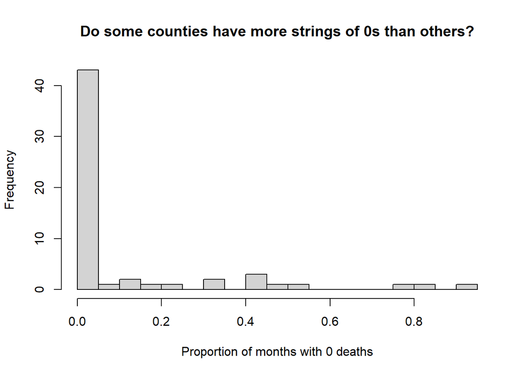

```r
hist(propzeros_total,breaks = 20 ,xlab = "Proportion of months with 0 deaths",main = "Do some counties have more strings of 0s than others?")
```

One aspect of the data that we wanted to examine before proceeding with our analysis was the frequency in which there were 0 deaths in a given county for a month. This would inform us about whether a standard Poisson model or a zero inflated Poisson model would be more appropriate. What I did above was first calculate the proportion of months (out of 72) that had 0 deaths observed for each county. Then identified which counties had a proportion of 0s greater than 75%, 85%, etc. Then, I made a histogram which shows there are only a couple of counties (which have very small populations) that had a high frequency of 0s. The aggregation performed in previous steps addressed the zero inflation it appears.

AGGREGATING MORTALITY DATA INTO CLUSTERS AS OPPOSED TO EACH COUNTY (ALSO AGGREGATED TO MORTALITY RATE PER CLUSTER)

Again, we want the number of respiratory related deaths at the cluster level, not the county level. So we once again aggregate the observations for each county in a given cluster. First, we simply add all the observations in cluster together to get a total number of respiratory related deaths for the months of 2014-2019 for each cluster. Then, we also calculated a mortality rate (per 100k people) for each cluster. This was done by taking the total number of deaths for a given cluster and dividing it by the total population of that cluster times 100,000 i.e. (deaths$*\frac{100000}{clusterpop}$). This second dataset will be used for our Gaussian process regression model which needs to be fit on a continuous response variable.

```r
#County populations by year pulled from SoA data
countypops = CA_data %>% filter(Year > 2013) %>% select(Total_Pop,County,Year) %>% unique()
countypops = cbind(countypops,Cluster = rep(clusterlabels$Cluster,each=6))

cluster_mortality_total = matrix(NA,nrow = 72,ncol = 8)

cluster_mortality_rate = matrix(NA,nrow = 72,ncol = 8)

for (i in 1:8){
  cluster = total.mortality.ts %>% filter(Cluster == i)
  year = 2014

  for(j in 1:72){
    col = cluster[,j+3]

    #Sum of deaths across counties in a cluster
    cluster_mortality_total[j,i] = sum(col)

    #Rate of deaths (per 100,000) across counties in a cluster
    pops = countypops %>% filter(Year == year,Cluster == i) %>% select(Total_Pop)
    cluster.pop = sum(pops)
    cluster_mortality_rate[j,i] = (sum(col)/cluster.pop)*100000

    if ((j>12) & (j<25)){
      year = 2015
    }

    else if ((j>24) & (j<37)){
      year = 2016
    }

    else if ((j>36) & (j<49)){
      year = 2017
    }

    else if ((j>48) & (j<61)){
      year = 2018
    }

    else if ((j>60) & (j<73)){
      year = 2019
    }

    else{
      year = 2014
    }
  }
}

#Time series of total deaths for each cluster
colnames(cluster_mortality_total) = c("Cluster 1","Cluster 2",
                                "Cluster 3","Cluster 4",
                                "Cluster 5","Cluster 6","Cluster 7","Cluster 8")
rownames(cluster_mortality_total) = colnames(total.mortality.ts[4:75])
cluster_mortality_total = data.frame(cluster_mortality_total)

head(cluster_mortality_total)
```

|  | Cluster.1 | Cluster.2 | Cluster.3 | Cluster.4 | Cluster.5 | Cluster.6 | Cluster.7 | Cluster.8 |
| --- | --- | --- | --- | --- | --- | --- | --- | --- |
| 1/2014 | 1101 | 80 | 80 | 310 | 55 | 15 | 329 | 273 |
| 2/2014 | 867 | 51 | 44 | 250 | 39 | 6 | 264 | 202 |
| 3/2014 | 854 | 47 | 42 | 235 | 32 | 15 | 261 | 177 |
| 4/2014 | 705 | 45 | 38 | 203 | 36 | 12 | 223 | 172 |
| 5/2014 | 710 | 45 | 36 | 196 | 31 | 17 | 207 | 153 |
| 6/2014 | 663 | 37 | 43 | 166 | 25 | 9 | 176 | 131 |

```r
#Time series of rate of deaths (per 100,000) for each cluster
colnames(cluster_mortality_rate) = c("Cluster 1","Cluster 2",
                                "Cluster 3","Cluster 4",
                                "Cluster 5","Cluster 6","Cluster 7","Cluster 8")
rownames(cluster_mortality_rate) = colnames(total.mortality.ts[4:75])
cluster_mortality_rate = data.frame(cluster_mortality_rate)

head(cluster_mortality_rate)
```

|  | Cluster.1 | Cluster.2 | Cluster.3 | Cluster.4 | Cluster.5 | Cluster.6 | Cluster.7 | Cluster.8 |
| --- | --- | --- | --- | --- | --- | --- | --- | --- |
| 1/2014 | 5.891607 | 6.635007 | 6.711308 | 5.944301 | 5.431745 | 6.013784 | 5.666252 | 5.638441 |
| 2/2014 | 4.639440 | 4.229817 | 3.691219 | 4.793791 | 3.851601 | 2.405513 | 4.546780 | 4.172033 |
| 3/2014 | 4.569875 | 3.898066 | 3.523437 | 4.506164 | 3.160288 | 6.013784 | 4.495112 | 3.655692 |
| 4/2014 | 3.772555 | 3.732191 | 3.187871 | 3.892558 | 3.555324 | 4.811027 | 3.840651 | 3.552424 |
| 5/2014 | 3.799310 | 3.732191 | 3.020089 | 3.758332 | 3.061529 | 6.815621 | 3.565089 | 3.160005 |
| 6/2014 | 3.547807 | 3.068691 | 3.607328 | 3.183077 | 2.468975 | 3.608270 | 3.031187 | 2.705625 |

```r
# #Removes Sept-Dec 2014 NAs
# cluster_mortality_total = na.omit(cluster_mortality_total)
```

MAKE A TIME SERIES FOR EACH CLUSTER:

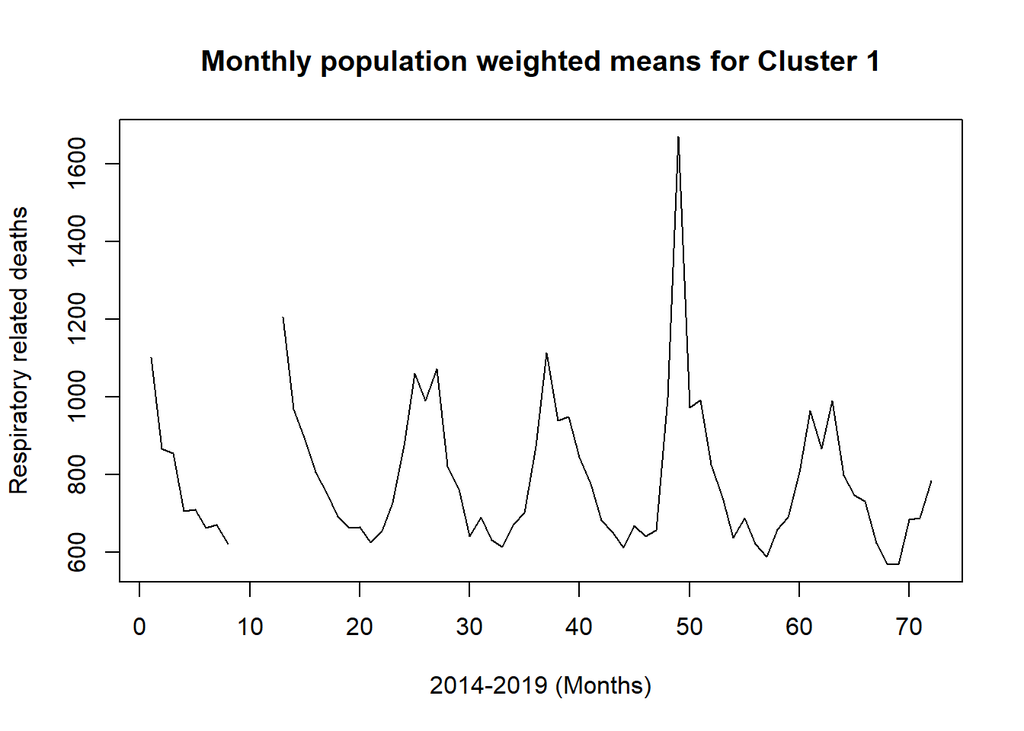

```r
plot(ts(cluster_mortality_total$Cluster.1),xlab = "2014-2019 (Months)",ylab = "Respiratory related deaths", main = "Monthly population weighted means for Cluster 1")
```

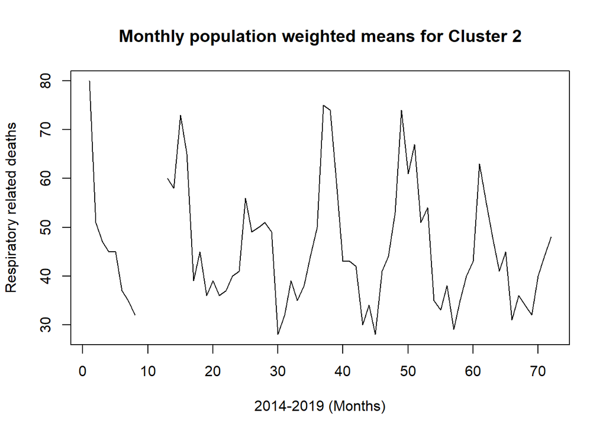

```r
plot(ts(cluster_mortality_total$Cluster.2),xlab = "2014-2019 (Months)",ylab = "Respiratory related deaths", main = "Monthly population weighted means for Cluster 2")
```

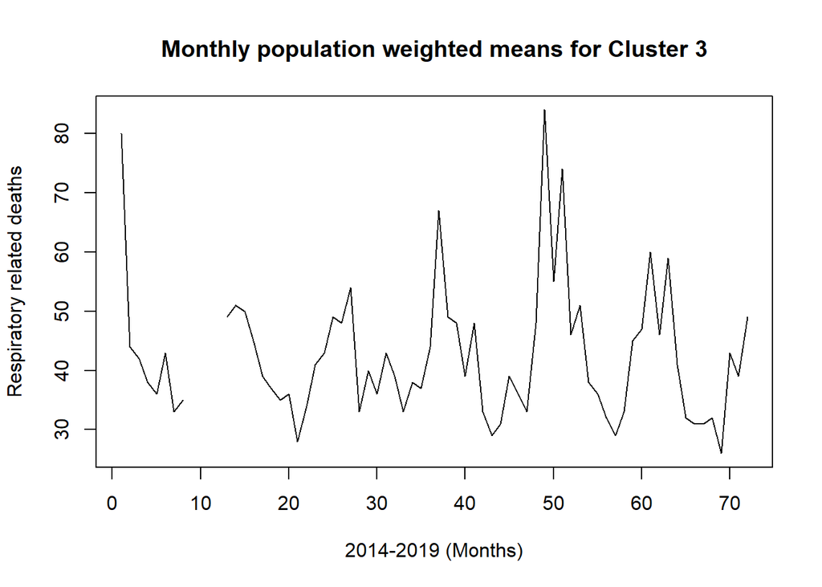

```r
plot(ts(cluster_mortality_total$Cluster.3),xlab = "2014-2019 (Months)",ylab = "Respiratory related deaths", main = "Monthly population weighted means for Cluster 3")
```

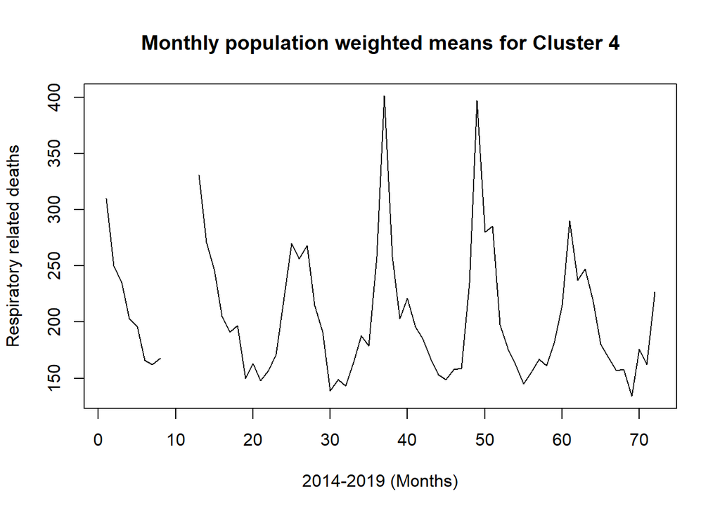

```r
plot(ts(cluster_mortality_total$Cluster.4),xlab = "2014-2019 (Months)",ylab = "Respiratory related deaths", main = "Monthly population weighted means for Cluster 4")
```

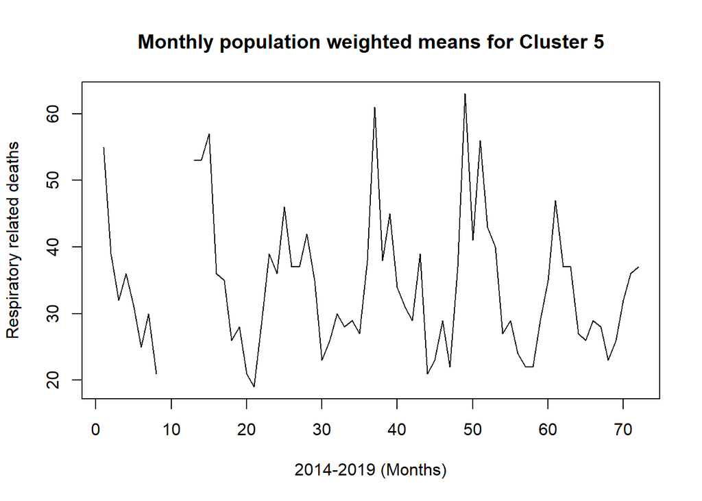

```r
plot(ts(cluster_mortality_total$Cluster.5),xlab = "2014-2019 (Months)",ylab = "Respiratory related deaths", main = "Monthly population weighted means for Cluster 5")
```

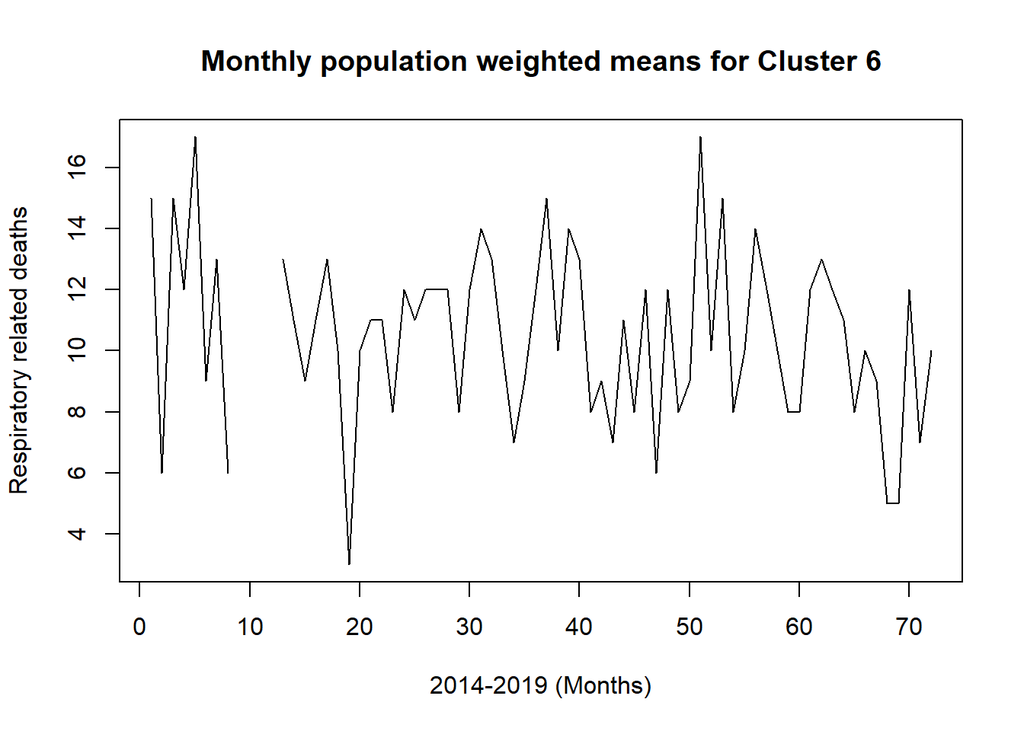

```r
plot(ts(cluster_mortality_total$Cluster.6),xlab = "2014-2019 (Months)",ylab = "Respiratory related deaths", main = "Monthly population weighted means for Cluster 6")
```

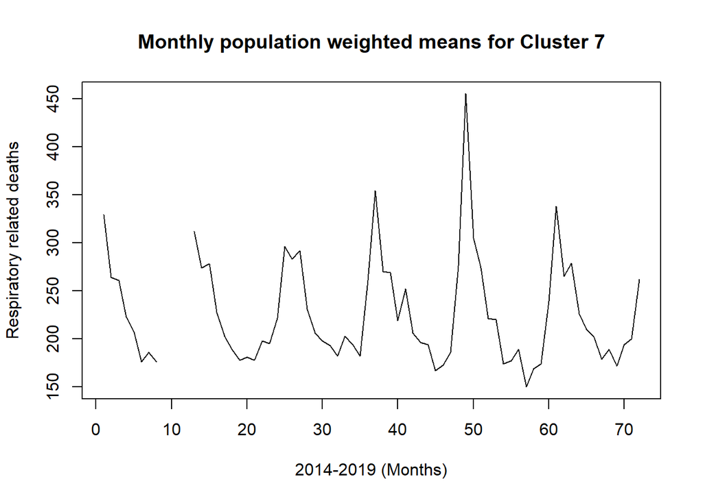

```r
plot(ts(cluster_mortality_total$Cluster.7),xlab = "2014-2019 (Months)",ylab = "Respiratory related deaths", main = "Monthly population weighted means for Cluster 7")
```

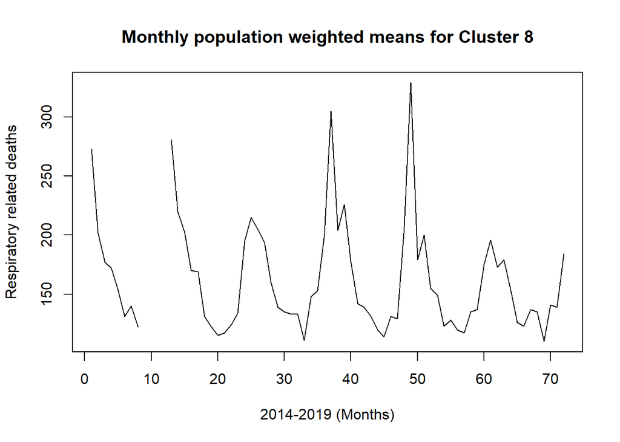

```r
plot(ts(cluster_mortality_total$Cluster.8),xlab = "2014-2019 (Months)",ylab = "Respiratory related deaths", main = "Monthly population weighted means for Cluster 8")
```

Now that all of the data from the SoA (used for SKATER and HUGE to get graph filter H), EPA (used to get gram matrix K), and Cal-ViDa (response) is downloaded, cleaned, and well formatted, we can now fit our kernel graph regression model as well as a few reference models, which we will compare against each other. For now, I have implemented a training-test data fitting approach to evaluating model performance.

First, I created a test dataset (inla_test_data) which has variables ID (which represents the cluster label), ID2 (which is basically an index label), response (cluster mortality), time (time index label 1-72), and months (month label 1-12). The response column inherently has NA values for time points 9-12 because those were not provided in the original Cal-ViDa dataset, but other than that, all observations are included. In the training dataset, I decided to hold out the last 3 months of the data (70-72 or Oct-Dec 2019) so I replaced those response values with NAs. This is how you get INLA to make predictions/forecasts because it does so based on the posterior predictive distribution.

Next, I created a second training dataset specifically for the GP regression model because we would be fitting the GP on the rates of death not the counts. The training dataset is called inla_gp_data. While the GP model will fit and predict a rate not a count, we still want to compare its predictions with respect to counts, so the test dataset is the same as before (inla_test_data). Once the predictions of rate of death per 100k are obtained from the GPR model, we will convert them back into counts using the cluster populations.

```r
response = t(cluster_mortality_total)
response = as.vector(response)
response = ceiling(response)

response2 = t(cluster_mortality_rate)
response2 = as.vector(response2)

id = rep(c(1:8),72)
id2 = 1:(8*72)
time = rep(c(1:72),each = 8)

inla_test_data = data.frame(id,id2,response,time)

inla_test_data2 = data.frame(id,id2,response2,time)

months = rep(c(1:12),each = 8)
months = rep(months,6)
inla_test_data = cbind(inla_test_data,months)

#Experimented with defining each of these as factors
# inla_test_data$id = factor(inla_test_data$id)
# inla_test_data$id2 = factor(inla_test_data$id2)
# inla_test_data$time = factor(inla_test_data$time)
inla_test_data$months = factor(inla_test_data$months)

# response = replace_na(response,0.01)
inla_gp_data = inla_test_data2

year = rep(2014:2019,each = 12)
inla_gp_data = cbind(inla_gp_data,year)

###Split into training and test dataset to "impute" missing values
inla_train_data = inla_test_data

#Remove missing data from dataset (rows 65-96)
inla_train_data = inla_train_data[-c(65:96),]

#Additionally omit values for months 70-72
omit_idx = which(inla_train_data$time >= 70)
inla_train_data$response[omit_idx] = NA

omit_idx = which(inla_gp_data$time >= 70)
inla_gp_data$response2[omit_idx] = NA
```

# Fit a simple Poisson GLMM for our mortality data

We wanted to compare the performance of our proposed model with a few reference models. The first one is a Poisson generalized linear mixed model. This model assumes the observed data follows a Poisson distribution and the hyperparameter $\lambda_i$ can be modeled using a mixed effects model with a log link.

In other words,

$Y_i \sim Pois(\lambda_i)$ for $i=1,...,8$ where $log(\lambda_i) = \beta_0 + \beta_1 months2 + ... + \beta_{11} months12 + u_i$

where $u_i$ is a random effect that is distributed $MVN(0,\tau \Sigma)$

We wanted the first reference model to be simple, so we assumed that the random effects $u_i$ are iid. This means that $\Sigma$ is simply a diagonal matrix of scaling factors. The hyperparameter $log(\tau)$ is by default assigned a $log \; \Gamma(1,0.00005)$ prior.

```r
#Fitting poisson glmm in INLA
#CHANGED TO MONTHS INSTEAD OF TIME
ref_formula1 = response ~ months + f(id,model = "iid") #could use id or id2
ref_model1 = inla(ref_formula1,family = "poisson",data = inla_train_data)

# summary(ref_model1)
ref_model1$summary.fixed
```

|  | mean | sd | 0.025quant | 0.5quant | 0.975quant | mode | kld |
| --- | --- | --- | --- | --- | --- | --- | --- |
| (Intercept) | 4.9248647 | 0.46869673 | 3.9867658 | 4.9248961 | 5.8627898 | 4.9249566 | 1.704396e-05 |
| months2 | -0.2456072 | 0.01276060 | -0.2706327 | -0.2456072 | -0.2205816 | -0.2456072 | 5.530138e-11 |
| months3 | -0.2338893 | 0.01271883 | -0.2588328 | -0.2338893 | -0.2089457 | -0.2338893 | 5.526845e-11 |
| months4 | -0.4172328 | 0.01341411 | -0.4435399 | -0.4172328 | -0.3909256 | -0.4172328 | 5.525983e-11 |
| months5 | -0.4890698 | 0.01371192 | -0.5159610 | -0.4890698 | -0.4621786 | -0.4890698 | 5.528438e-11 |
| months6 | -0.6045903 | 0.01422279 | -0.6324833 | -0.6045903 | -0.5766972 | -0.6045903 | 5.529453e-11 |
| months7 | -0.6289576 | 0.01433578 | -0.6570722 | -0.6289576 | -0.6008429 | -0.6289576 | 5.543928e-11 |
| months8 | -0.6732236 | 0.01454583 | -0.7017503 | -0.6732236 | -0.6446970 | -0.6732236 | 5.542388e-11 |
| months9 | -0.7084047 | 0.01567230 | -0.7391405 | -0.7084047 | -0.6776689 | -0.7084047 | 5.548339e-11 |
| months10 | -0.6228444 | 0.01647135 | -0.6551472 | -0.6228444 | -0.5905415 | -0.6228444 | 5.529480e-11 |

[output cut: 2 more lines]

```r
bri.hyperpar.summary(ref_model1)
```

```
##               mean        sd    q0.025     q0.5   q0.975     mode
## SD for id 1.321342 0.3496036 0.8319566 1.255606 2.193969 1.149935
```

```r
preds_ref_model1 = ref_model1$summary.fitted.values
preds_ref_model1$mean = round(preds_ref_model1$mean)
preds_ref_model1 = cbind(inla_train_data$id,inla_train_data$time,preds_ref_model1)
colnames(preds_ref_model1) = c("id","time","mean","sd","0.025quant",
                               "0.5quant","0.975quant","mode")

#Exponentiating parameter to get better interpretation of estimates
multeff <- exp(ref_model1$summary.fixed$mean)
names(multeff) <- ref_model1$names.fixed
multeff
```

```
## (Intercept)     months2     months3     months4     months5     months6
## 137.6707101   0.7822295   0.7914495   0.6588675   0.6131965   0.5462982
##     months7     months8     months9    months10    months11    months12
##   0.5331473   0.5100617   0.4924291   0.5364165   0.5602168   0.7306785
```

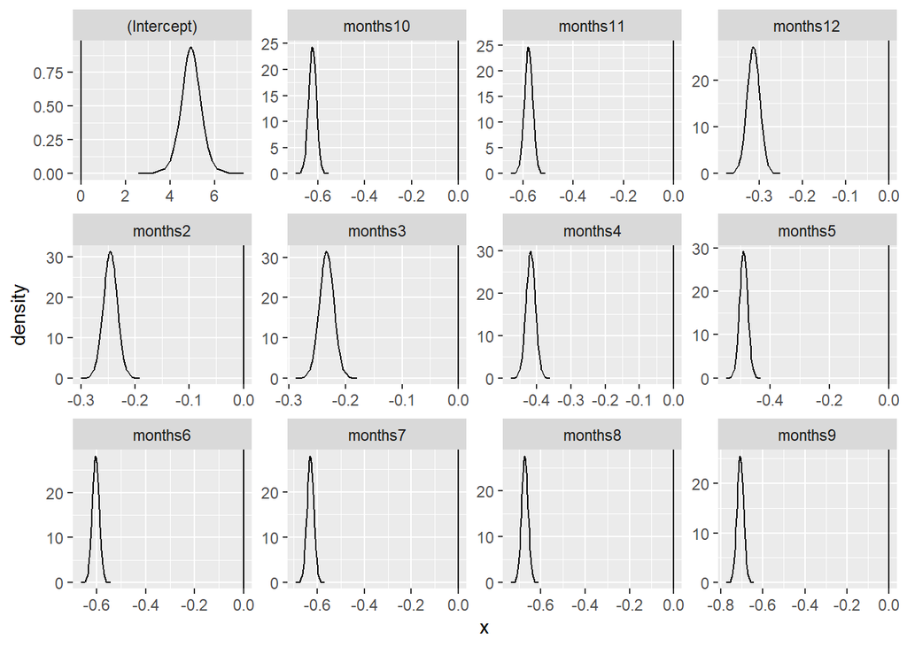

```r
#Plot of each parameters' posterior density
mf <- melt(ref_model1$marginals.fixed)
cf <- spread(mf,Var2,value)
names(cf)[2] <- 'parameter'
ggplot(cf,aes(x=x,y=y)) + geom_line()+facet_wrap(~ parameter,
           scales="free") + geom_vline(xintercept=0) + ylab("density")
```

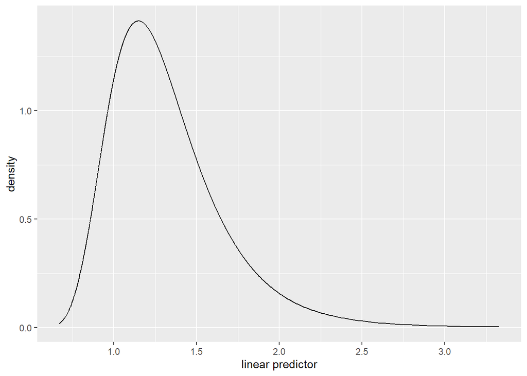

```r
# #Could also use
# bri.fixed.plot(ref_model1) #option to plot them together = TRUE

#Plot of precision of random effect (main hyperparameter of interest)
sden <- data.frame(bri.hyper.sd(ref_model1$marginals.hyperpar[[1]]))
    ggplot(sden,aes(x,y)) + geom_line() + ylab("density") +
           xlab("linear predictor")
```

```r
# #Could also use
# bri.hyperpar.plot(ref_model1)
```

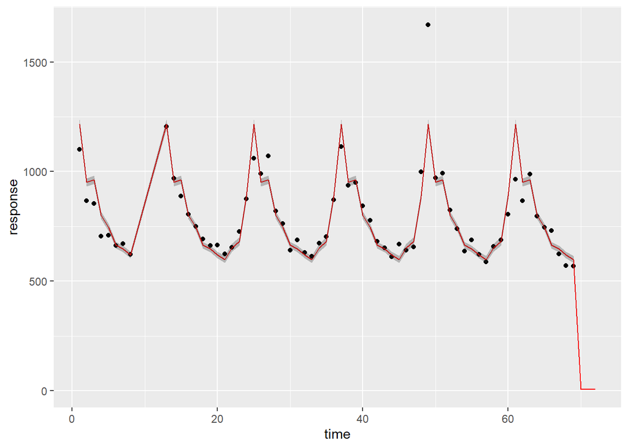

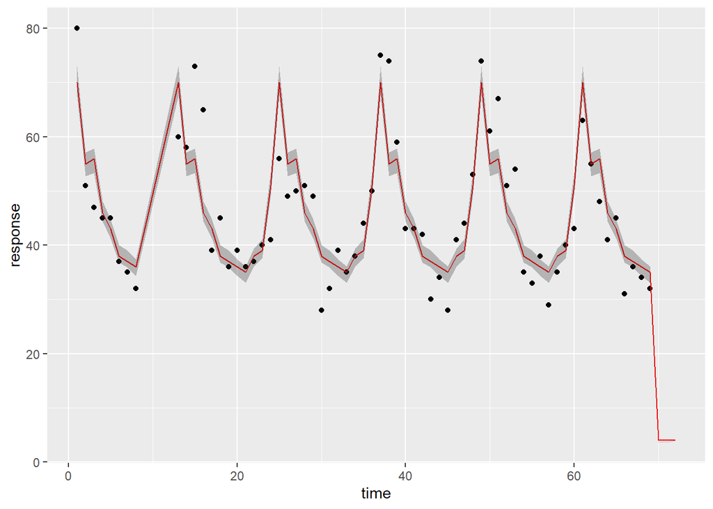

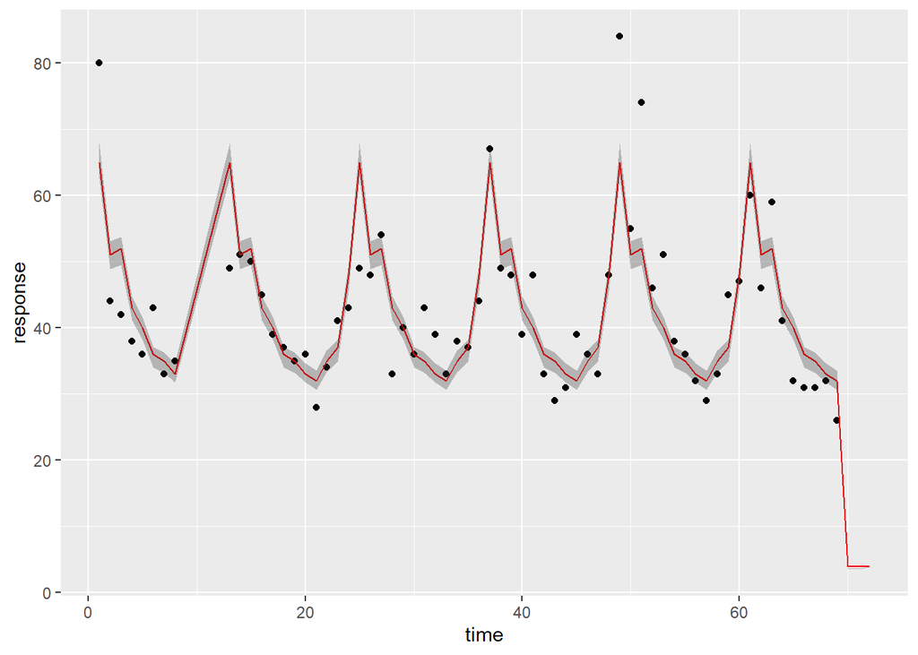

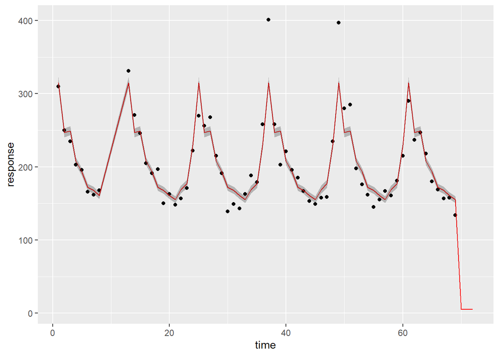

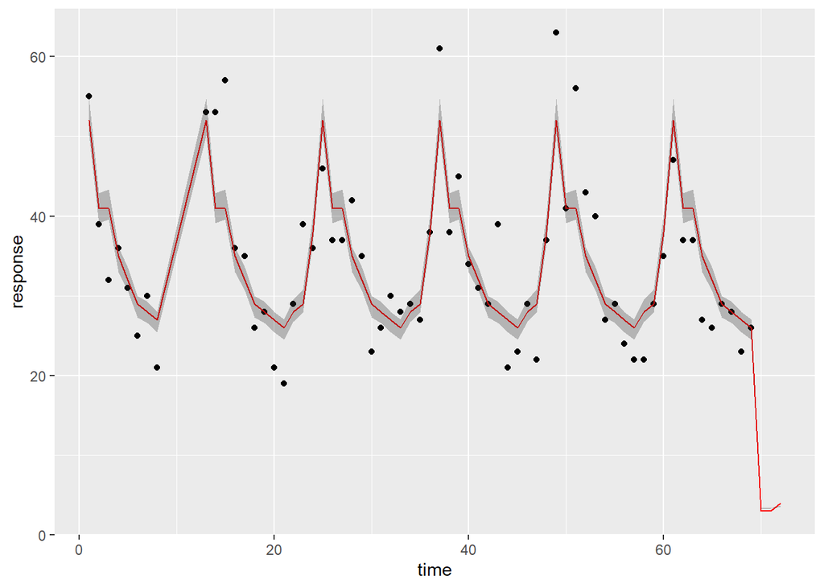

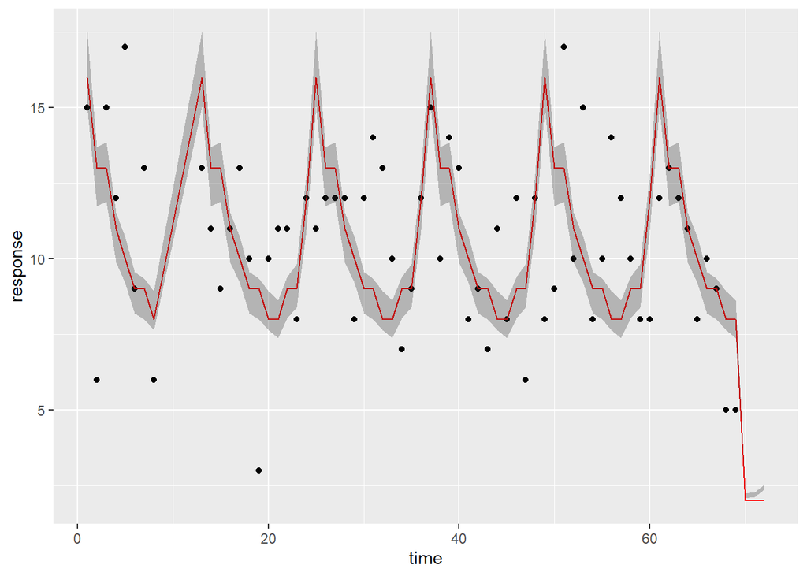

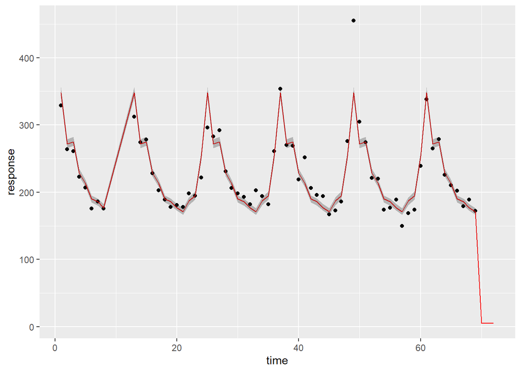

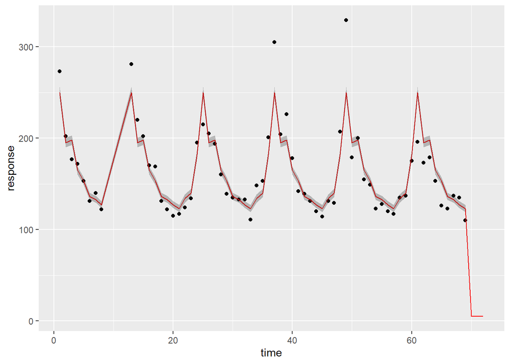

```r
#Plot of posterior predictive estimates with credible interval bands OVERLAID on response

for (i in 1:num_clus){
  df = inla_train_data %>% filter(id == i) %>% select(response)
  preds = preds_ref_model1 %>% filter(id == i)
  df = cbind(df,preds)

  post_pred_plot = df %>% ggplot(aes(x=time,y=response)) + geom_point() +
    geom_line(aes(y=mean),color = "red") + geom_ribbon(aes(ymin = `0.025quant`,ymax = `0.975quant`),alpha = 0.3)
  print(post_pred_plot)
}
```

```r
# #One call to ggplot (doesn't look as good)
# preds_ref_model1 %>% ggplot(aes(x=time,y=mean)) + geom_line() + geom_ribbon(aes(ymin = `0.025quant`,ymax = `0.975quant`),alpha = 0.3) + facet_wrap(~ id)

# #Combine plots with library patchwork
# pp_plot_ref_model1.1 = preds_ref_model1 %>% filter(id == 1) %>% ggplot(aes(x=time,y=mean)) + geom_line() + geom_ribbon(aes(ymin = `0.025quant`,ymax = `0.975quant`),alpha = 0.3)
#
# pp_plot_ref_model1.2 = preds_ref_model1 %>% filter(id == 2) %>% ggplot(aes(x=time,y=mean)) + geom_line() + geom_ribbon(aes(ymin = `0.025quant`,ymax = `0.975quant`),alpha = 0.3)
#
# pp_plot_ref_model1.3 = preds_ref_model1 %>% filter(id == 3) %>% ggplot(aes(x=time,y=mean)) + geom_line() + geom_ribbon(aes(ymin = `0.025quant`,ymax = `0.975quant`),alpha = 0.3)
#
# pp_plot_ref_model1.4 = preds_ref_model1 %>% filter(id == 4) %>% ggplot(aes(x=time,y=mean)) + geom_line() + geom_ribbon(aes(ymin = `0.025quant`,ymax = `0.975quant`),alpha = 0.3)
#
# pp_plot_ref_model1.5 = preds_ref_model1 %>% filter(id == 5) %>% ggplot(aes(x=time,y=mean)) + geom_line() + geom_ribbon(aes(ymin = `0.025quant`,ymax = `0.975quant`),alpha = 0.3)
#
# pp_plot_ref_model1.6 = preds_ref_model1 %>% filter(id == 6) %>% ggplot(aes(x=time,y=mean)) + geom_line() + geom_ribbon(aes(ymin = `0.025quant`,ymax = `0.975quant`),alpha = 0.3)
#
# pp_plot_ref_model1.7 = preds_ref_model1 %>% filter(id == 7) %>% ggplot(aes(x=time,y=mean)) + geom_line() + geom_ribbon(aes(ymin = `0.025quant`,ymax = `0.975quant`),alpha = 0.3)
#
# pp_plot_ref_model1.8 = preds_ref_model1 %>% filter(id == 8) %>% ggplot(aes(x=time,y=mean)) + geom_line() + geom_ribbon(aes(ymin = `0.025quant`,ymax = `0.975quant`),alpha = 0.3)
#
# pp_plot_ref_model1.1 + pp_plot_ref_model1.2 + pp_plot_ref_model1.3 + pp_plot_ref_model1.4 + pp_plot_ref_model1.5 + pp_plot_ref_model1.6 + pp_plot_ref_model1.7 + pp_plot_ref_model1.8
```

# Fitting a Besag-York-Mollie model (gives same model?)

For our second reference model, we decided to fit a Besag-York-Mollie model, which is a log-normal Poisson model with an intrinsic conditional autoregressive component to capture spatial autocorrelations i.e. a Besag model, plus a standard random effects term which is included to capture non-spatial heterogeneity. Obviously, this model is less naive than reference model 1 because it does not assume iid random effects.

The BYM model can be written as,

$Y_i \sim Pois(\lambda_i)$ for $i=1,...,8$ where $log(\lambda_i) = \beta_0 + \beta_1 months2 + ... + \beta_{11} months12 + \phi + u_i$

where $p(\phi) \propto exp(-\frac{1}{2} \sum_{i \sim j} (\phi_i - \phi_j)^2)$ and $u_i$ is still a standard random effect that is distributed $MVN(0,\tau \Sigma)$.

Note: it is more commonly known that ICAR components are conditionally normally distributed.

As one can see below, the summary outputs indicate that this model is very similar to the Poisson GLMM (reference model 1). The intercept and SD for the random effect component are estimated to almost the exact same as those estimated by the Poisson GLMM, indicating that including the spatial ICAR component is seemingly not very impactful.

```r
ref_formula2 = response ~ months + f(id, model = "bym", graph = huge.est) #ID2 in formula results in error
ref_model2 = inla(ref_formula2,family = "poisson",data = inla_train_data)

ref_model2$summary.fixed
```

|  | mean | sd | 0.025quant | 0.5quant | 0.975quant | mode | kld |
| --- | --- | --- | --- | --- | --- | --- | --- |
| (Intercept) | 4.9248705 | 0.46433733 | 4.0002316 | 4.9248991 | 5.8493536 | 4.9249552 | 2.311573e-05 |
| months2 | -0.2456062 | 0.01276060 | -0.2706317 | -0.2456062 | -0.2205807 | -0.2456062 | 5.525877e-11 |
| months3 | -0.2338883 | 0.01271883 | -0.2588319 | -0.2338883 | -0.2089448 | -0.2338883 | 5.527918e-11 |
| months4 | -0.4172320 | 0.01341411 | -0.4435391 | -0.4172320 | -0.3909249 | -0.4172320 | 5.522127e-11 |
| months5 | -0.4890691 | 0.01371192 | -0.5159603 | -0.4890691 | -0.4621779 | -0.4890691 | 5.528438e-11 |
| months6 | -0.6045896 | 0.01422279 | -0.6324827 | -0.6045896 | -0.5766965 | -0.6045896 | 5.543174e-11 |
| months7 | -0.6289570 | 0.01433578 | -0.6570716 | -0.6289570 | -0.6008423 | -0.6289570 | 5.530423e-11 |
| months8 | -0.6732231 | 0.01454583 | -0.7017497 | -0.6732231 | -0.6446965 | -0.6732231 | 5.516151e-11 |
| months9 | -0.7084043 | 0.01567230 | -0.7391401 | -0.7084043 | -0.6776684 | -0.7084043 | 5.525739e-11 |
| months10 | -0.6228440 | 0.01647135 | -0.6551468 | -0.6228440 | -0.5905411 | -0.6228440 | 5.529480e-11 |

[output cut: 2 more lines]

```r
bri.hyperpar.summary(ref_model2)
```

```
##                                     mean         sd    q0.025       q0.5
## SD for id (idd component)     1.32008487 0.32374773 0.8318835 1.26725236
## SD for id (spatial component) 0.03337894 0.02031821 0.0122266 0.02750644
##                                   q0.975       mode
## SD for id (idd component)     2.09366727 1.16439528
## SD for id (spatial component) 0.08826289 0.01996466
```

```r
preds_ref_model2 = ref_model2$summary.fitted.values
preds_ref_model2$mean = round(preds_ref_model2$mean)
preds_ref_model2 = cbind(inla_train_data$id,inla_train_data$time,preds_ref_model2)
colnames(preds_ref_model2) = c("id","time","mean","sd","0.025quant",
                               "0.5quant","0.975quant","mode")

#Exponentiating parameter to get better interpretation of estimates
multeff <- exp(ref_model2$summary.fixed$mean)
names(multeff) <- ref_model2$names.fixed
multeff
```

```
## (Intercept)     months2     months3     months4     months5     months6
## 137.6715072   0.7822302   0.7914502   0.6588681   0.6131970   0.5462986
##     months7     months8     months9    months10    months11    months12
##   0.5331476   0.5100620   0.4924294   0.5364167   0.5602170   0.7306789
```

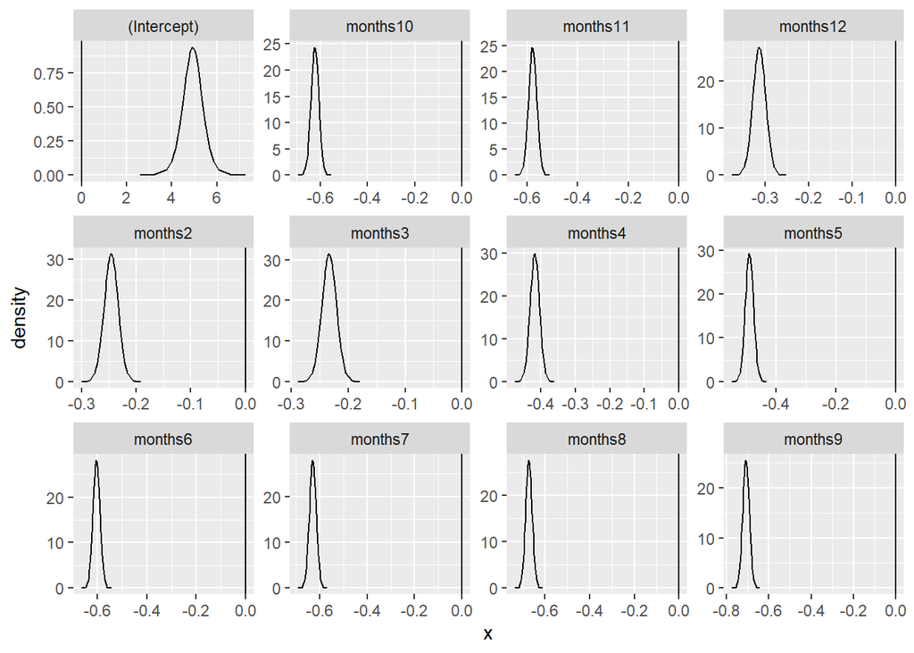

```r
#Plot of each parameters' posterior density
mf <- melt(ref_model2$marginals.fixed)
cf <- spread(mf,Var2,value)
names(cf)[2] <- 'parameter'
ggplot(cf,aes(x=x,y=y)) + geom_line()+facet_wrap(~ parameter,
           scales="free") + geom_vline(xintercept=0) + ylab("density")
```

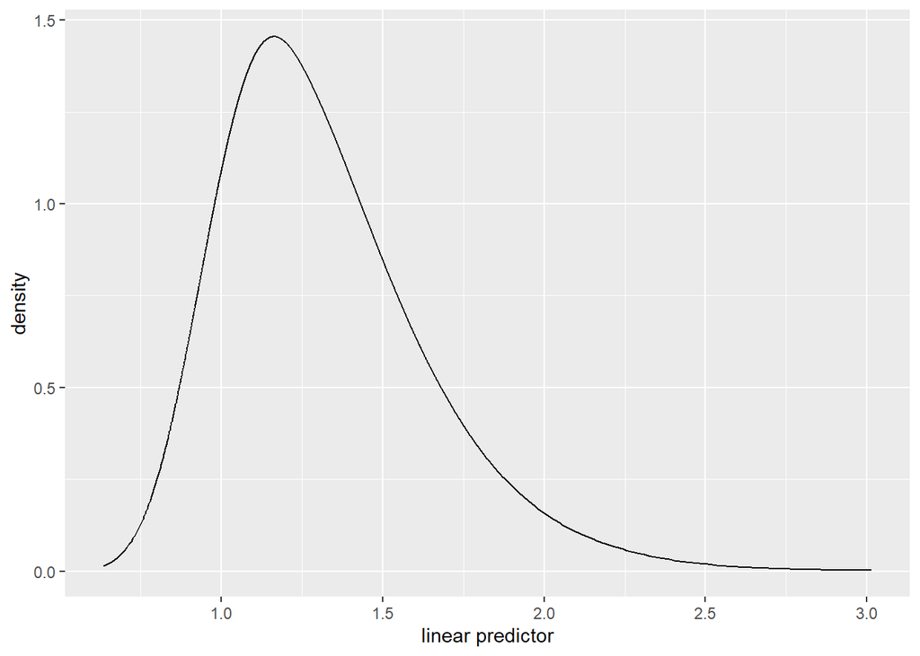

```r
# #Could also use
# bri.fixed.plot(ref_model2) #option to plot them together = TRUE

#Plot of precision of random effect (main hyperparameter of interest)
sden <- data.frame(bri.hyper.sd(ref_model2$marginals.hyperpar[[1]]))
    ggplot(sden,aes(x,y)) + geom_line() + ylab("density") +
           xlab("linear predictor")
```

```r
# #Could also use
# bri.hyperpar.plot(ref_model2)
```